# Austin Animal Center Data Exploration and Classification

Nathan Martinez

June 21, 2016

## Introduction

In this project, I will be using data from the Austin Animal Center to predict the outcomes of animals from their animal shelters. The data set includes 9 predictor variables (not all of which are useful) for 38185 different cats and dogs from animal shelters in Austin, TX, and the response variable we are trying to predict is `OutcomeType` (this is the type of outcome for each animal at the animal shelters). I will first import the data, then explore the relationship between the response variable and each predictor variable, then perform some quick feature engineering and missing value imputation, and finally build a random forest classification model to predict the outcomes of animals from the test data set. Shoutout to Megan Risdal for some inspiration. Let the fun begin!

## Importing the Data

First, let’s import both the test and training data sets. I will join them together to make feature engineering easier, and add a variable to each data set to denote whether the observation belongs to the test or training data set in order to keep track of which observations come from which data sets.

```r
#importing data
train<-read.csv("./train.csv",header=T)
test<-read.csv("./test.csv",header=T)

#using str() to take a quick look at both data sets
str(train)
```

```
## 'data.frame':    26729 obs. of  10 variables:
##  $ AnimalID      : Factor w/ 26729 levels "A006100","A047759",..: 5420 1604 11614 10239 3502 7396 17152 18183 5373 7574 ...
##  $ Name          : Factor w/ 6375 levels "","'Stache"," Joanie",..: 2353 1849 4442 1 1 1837 2763 1 3458 1 ...
##  $ DateTime      : Factor w/ 22918 levels "2013-10-01 09:31:00",..: 3362 351 12682 7191 1234 5022 13873 14619 3214 5210 ...
##  $ OutcomeType   : Factor w/ 5 levels "Adoption","Died",..: 4 3 1 5 5 5 5 5 1 1 ...
##  $ OutcomeSubtype: Factor w/ 17 levels "","Aggressive",..: 1 17 8 14 14 14 14 14 1 13 ...
##  $ AnimalType    : Factor w/ 2 levels "Cat","Dog": 2 1 2 1 2 2 1 1 2 2 ...
##  $ SexuponOutcome: Factor w/ 6 levels "","Intact Female",..: 4 5 4 3 4 2 3 6 5 5 ...
##  $ AgeuponOutcome: Factor w/ 45 levels "","0 years","1 day",..: 7 7 23 27 23 4 27 27 34 7 ...
##  $ Breed         : Factor w/ 1380 levels "Abyssinian Mix",..: 1222 641 1067 641 915 370 641 641 46 365 ...
##  $ Color         : Factor w/ 366 levels "Agouti","Agouti/Brown Tabby",..: 131 168 87 43 275 37 64 105 251 319 ...
```

```r
str(test)
```

```
## 'data.frame':    11456 obs. of  8 variables:
##  $ ID            : int  1 2 3 4 5 6 7 8 9 10 ...
##  $ Name          : Factor w/ 3713 levels "","010314","3Ds",..: 3234 646 1347 2652 3083 237 355 8 2885 2884 ...
##  $ DateTime      : Factor w/ 10575 levels "2013-10-01 10:44:00",..: 9038 3617 10140 1069 8816 7432 1797 3094 4995 2092 ...
##  $ AnimalType    : Factor w/ 2 levels "Cat","Dog": 2 2 1 2 2 2 1 1 2 2 ...
##  $ SexuponOutcome: Factor w/ 5 levels "Intact Female",..: 1 4 3 2 3 3 3 4 4 4 ...
##  $ AgeuponOutcome: Factor w/ 46 levels "","0 years","1 day",..: 8 23 7 31 23 29 13 39 27 7 ...
##  $ Breed         : Factor w/ 913 levels "Abyssinian Mix",..: 543 461 408 346 634 111 406 408 227 698 ...
##  $ Color         : Factor w/ 277 levels "Agouti","Apricot",..: 186 29 80 230 239 96 85 80 24 96 ...
```

```r
#correcting column names and converting all column classes to character so the two data sets can be joined
colnames(test)[1]<-"AnimalID"
for(i in 1:ncol(train)){
      train[,i]<-as.character(train[,i])
}
for(i in 1:ncol(test)){
      test[,i]<-as.character(test[,i])
}

#adding variable to distinguish between training and test observations
train$data<-"train"
test$data<-"test"

#loading dplyr for bind_rows()
suppressMessages(require(dplyr))

#merging both data sets to make feature engineering easier
full<-data.frame(bind_rows(train,test))

#converting certain variables back to factor
full$OutcomeType<-factor(full$OutcomeType)
full$OutcomeSubtype<-factor(full$OutcomeSubtype)
full$AnimalType<-factor(full$AnimalType)
full$SexuponOutcome<-factor(full$SexuponOutcome)
full$AgeuponOutcome<-factor(full$AgeuponOutcome)
full$data<-factor(full$data)
full$Breed<-factor(full$Breed)
full$Color<-factor(full$Color)

#bringing up summary(full) to check everything out
summary(full)
```

```
##    AnimalID             Name             DateTime                  OutcomeType      OutcomeSubtype
##  Length:38185       Length:38185       Length:38185       Adoption       :10769            :13612
##  Class :character   Class :character   Class :character   Died           :  197   Partner  : 7816
##  Mode  :character   Mode  :character   Mode  :character   Euthanasia     : 1555   Foster   : 1800
##                                                           Return_to_owner: 4786   SCRP     : 1599
##                                                           Transfer       : 9422   Suffering: 1002
##                                                           NA's           :11456   (Other)  :  900
##                                                                                   NA's     :11456
##  AnimalType        SexuponOutcome   AgeuponOutcome                       Breed
##  Cat:15934                :    1   1 year  : 5737   Domestic Shorthair Mix  :12587
##  Dog:22251   Intact Female: 5004   2 years : 5383   Pit Bull Mix            : 2776
##              Intact Male  : 4985   2 months: 4929   Chihuahua Shorthair Mix : 2498
##              Neutered Male:14014   3 years : 2589   Labrador Retriever Mix  : 1949
##              Spayed Female:12633   3 months: 1788   Domestic Medium Hair Mix: 1217
##              Unknown      : 1548   1 month : 1782   German Shepherd Mix     :  830
##                                    (Other) :15977   (Other)                 :16328
##                Color          data
##  Black/White      : 4043   test :11456
##  Black            : 3265   train:26729
##  Brown Tabby      : 2359
##  Brown Tabby/White: 1333
##  White            : 1333
##  Brown/White      : 1257
##  (Other)          :24595
```

## Inspecting and Cleaning the Data, Feature Engineering, and Imputing Missing Values

In the above `summary(full)` output, we get a quick glimpse of each variable. In this section, I will explore each variable in greater detail, create new predictor variables out of old ones as I go along, and correct missing values where I encounter them.

### Name

Let’s take a look at our fist variable, `Name`. I wouldn’t think that an animal’s name would have much bearing on its outcome, but thanks to some inspiration from Megan Risdal I have learned to think otherwise.

```r
full$Name[1:20]
```

```
##  [1] "Hambone" "Emily"   "Pearce"  ""        ""        "Elsa"    "Jimmy"   ""        "Lucy"    ""
## [11] ""        ""        "Rocket"  "Scooter" "Preston" "Oliver"  ""        ""        "Chrissy" "Kuma"
```

```r
summary(full$Name)
```

```
##    Length     Class      Mode
##     38185 character character
```

At first glance, we can tell that a bunch of animals don’t have any names. Let’s make a new variable that captures whether or not an animal has a name and see if it has any effect on `OutcomeType`.

```r
#making our nameless variable
full$nameless<-ifelse(full$Name=="","Nameless","Named")
full$nameless<-factor(full$nameless,levels=c("Named","Nameless"))
full[1:20,] %>% select(Name,nameless)
```

```
##       Name nameless
## 1  Hambone    Named
## 2    Emily    Named
## 3   Pearce    Named
## 4          Nameless
## 5          Nameless
## 6     Elsa    Named
## 7    Jimmy    Named
## 8          Nameless
## 9     Lucy    Named
## 10         Nameless
## 11         Nameless
## 12         Nameless
## 13  Rocket    Named
## 14 Scooter    Named
## 15 Preston    Named
## 16  Oliver    Named
## 17         Nameless
## 18         Nameless
## 19 Chrissy    Named
## 20    Kuma    Named
```

```r
summary(full$nameless)
```

```
##    Named Nameless
##    27269    10916
```

Alright, it looks like our new `nameless` variable is working like its supposed to. Now lets plot it out and see if there’s a relationship between whether or not an animal has a name and what outcome it ends up having.

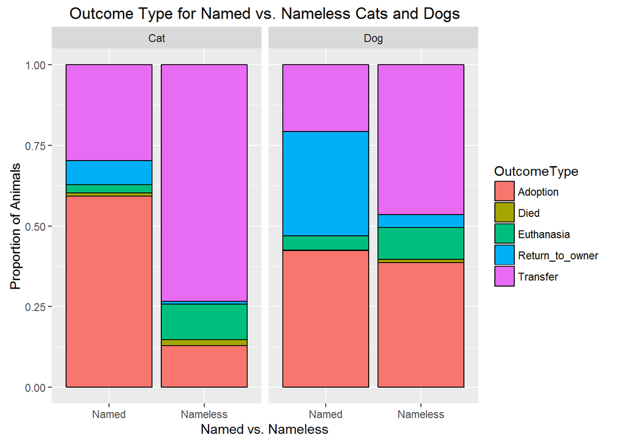

```r
#loading ggplot2 for graphics
suppressMessages(require(ggplot2))

#plotting out our nameless variable
ggplot(full[full$data=="train",],aes(x=nameless,fill=OutcomeType))+
      geom_bar(position="fill",color="black")+
      facet_grid(.~AnimalType)+
      labs(x="Named vs. Nameless",y="Proportion of Animals",title="Outcome Type for Named vs. Nameless Cats and Dogs")
```

Very interesting, it appears that there is indeed a stark difference between outcomes for nameless cats and dogs versus those with names. Named animals are much less likely to get transfered than nameless animals, and named animals are also substantially less likely to die or be euthanized. The difference between likelihoods of dying or getting euthanized for named versus unnamed animals makes sense; if a cat or dog enters an animal shelter without a name, it was probably living on the streets longer, lost its nametag from being out there for so long, and thus was found in poorer health than a named animal. Nameless animals are also much less likely to be returned to their owners, which makes sense since animals that are lacking names are probably also lacking contact information for their owners. Interestingly though, named cats are much more likely to be adopted than unnamed cats, but named dogs have just about the same likelihood of adoption as nameless ones.

Since our new variable `nameless` offers significant insight into animals’ outcomes, **it will be included in our final model**.

### DateTime

Let’s look at the variable `DateTime`.

```r
full$DateTime[1:20]
```

```
##  [1] "2014-02-12 18:22:00" "2013-10-13 12:44:00" "2015-01-31 12:28:00" "2014-07-11 19:09:00"
##  [5] "2013-11-15 12:52:00" "2014-04-25 13:04:00" "2015-03-28 13:11:00" "2015-04-30 17:02:00"
##  [9] "2014-02-04 17:17:00" "2014-05-03 07:48:00" "2013-12-05 15:50:00" "2013-11-04 14:48:00"
## [13] "2016-02-03 11:27:00" "2015-06-08 16:30:00" "2015-11-25 15:00:00" "2014-07-12 12:10:00"
## [17] "2014-05-03 16:15:00" "2014-06-07 12:54:00" "2014-05-17 11:32:00" "2014-07-30 17:34:00"
```

```r
summary(full$DateTime)
```

```
##    Length     Class      Mode
##     38185 character character
```

It would appear that `full$DateTime` contains a bunch of date and time values. As such, we should convert this variable to class `POSIXct`.

```r
full$DateTime<-as.POSIXct(strptime(full$DateTime, "%Y-%m-%d %H:%M:%S"))
full$DateTime[1:20]
```

```
##  [1] "2014-02-12 18:22:00 PST" "2013-10-13 12:44:00 PDT" "2015-01-31 12:28:00 PST" "2014-07-11 19:09:00 PDT"
##  [5] "2013-11-15 12:52:00 PST" "2014-04-25 13:04:00 PDT" "2015-03-28 13:11:00 PDT" "2015-04-30 17:02:00 PDT"
##  [9] "2014-02-04 17:17:00 PST" "2014-05-03 07:48:00 PDT" "2013-12-05 15:50:00 PST" "2013-11-04 14:48:00 PST"
## [13] "2016-02-03 11:27:00 PST" "2015-06-08 16:30:00 PDT" "2015-11-25 15:00:00 PST" "2014-07-12 12:10:00 PDT"
## [17] "2014-05-03 16:15:00 PDT" "2014-06-07 12:54:00 PDT" "2014-05-17 11:32:00 PDT" "2014-07-30 17:34:00 PDT"
```

```r
class(full$DateTime)
```

```
## [1] "POSIXct" "POSIXt"
```

On its own, I don’t think `DateTime` will offer much insight into how animals end up at an animal shelter. For `DateTime` to offer insight into animals’ outcomes, there would have to be some type of relationship between `DateTime` and `OutcomeType` such that as `DateTime` increases, certain classes of `OutcomeType` become more or less likely to occur. For example, there would have to be periods of time where the amount of animals getting adopted is falling consistently relative to other outcomes or the amount of animals getting transfered is rising consistently relative to other outcome.

To make sure there aren’t any clear trends over time in the `DateTime` variable for each `OutcomeType`, let’s make a density plot of `DateTime` for each possible outcome type and see how the densities vary for each outcome. This will show the amount of animals in each `OutcomeType` over all of our ranges of dates and times. Again, if one outcome type is moving in a certain direction while others aren’t, then `DateTime` may actually offer some insight into how animals end up since this would indicate that there’s some type of relationship between `DateTime` and `OutcomeType`. If all the density curves appear to move together, this would indicate that there’s no relationship between `DateTime` and `OutcomeType` and that `DateTime` doesn’t offer any insight into how animal outcomes occur.

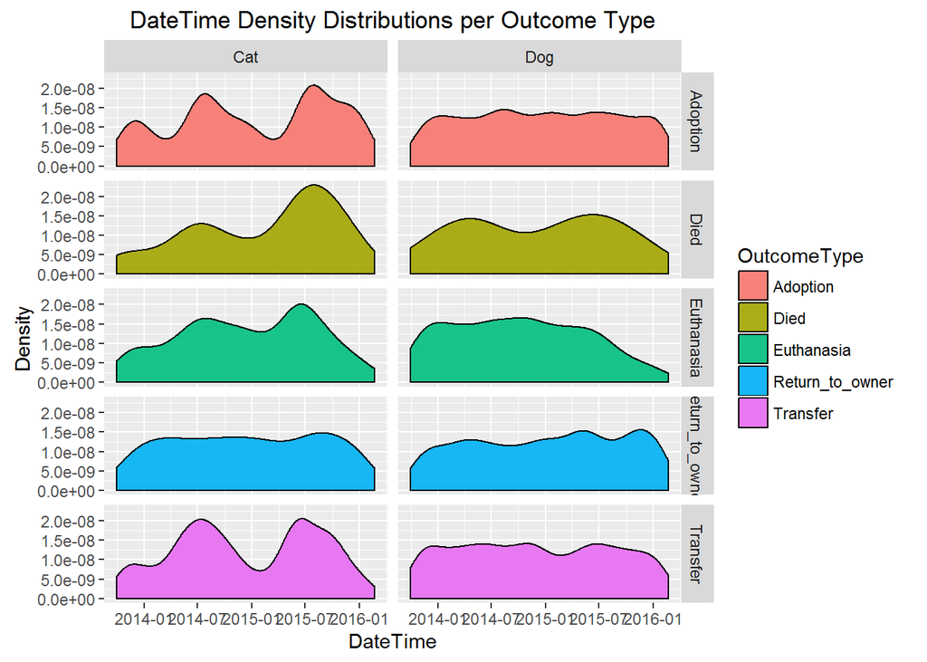

```r
#plotting density curves
ggplot(full[full$data=="train",],aes(x=DateTime,fill=OutcomeType))+
      geom_density(alpha=0.9)+
      facet_grid(OutcomeType~AnimalType)+
      labs(y="Density",title="DateTime Density Distributions per Outcome Type")
```

Looking at the graph, there do seem to be some brief trends in the density curves for cats and dogs, but nothing incredibly compelling. Remember, a strong relationship between `DateTime` and `OutcomeType` would manifest itself in this plot as certain outcome types moving in one direction while others move in a different direction as time increases; there doesn’t appear to be anything as clear and noticeable as that in this plot. There are a few interesting things to note about the data, though, like how the density curves for cats seem to have two noticeable spikes around July 2014 and July 2015 (with the exception of `Return_to_owner`) while dogs do not. Why is it that cats have more activity in the month of July? Also, the density curve for cats being returned to their owners exhibits no spikes in the July months, so this would mean that cats are less likely to get returned to their owners in July, relative to other outcomes. The dog density curves seem to have no clear trends though. Could there be some seasonal impact on cat outcomes? I originally created this plot with both cats and dogs wrapped up into the same density curves, but after recreating the plot with each `AnimalType` separated, it would appear that there’s something more going on here. Interesting stuff.

So what can we do to our `DateTime` variable to make it more meaningful? Well, I have a few ideas of new variables we can create from the `DateTime` variable that might be more insightful than what we have now. First, we could create a time of day variable for morning, afternoon, evening, and night (inspiration from Megan Risdal); the idea here is that maybe certain animal outcomes are more likely to happen at certain times of day (maybe more adoptions happen during the afternoon when people get off work?). Secondly, we could create a variable that distinguishes between seasons (fall, winter, spring, and summer) to try to capture some of the seasonal effects we saw in the `DateTime` variable. Finally, we can try making a categorical variable that distinguishes between either day of the week or weekday/weekend; maybe more adoptions happen on the weekend or on a Friday, for example. I will create these variables below and examine their ability to explain changes in the response variable `OutcomeType`.

#### Time of Day

Here I’ll create our time of day variable to represent times as either morning (05:00-11:00), afternoon (11:00-16:00), evening (16:00-22:00), or night (22:00-05:00). The time values I chose are subjective, but I feel that they adequately represent the four main times of day without bringing messy minutes into play. Credit goes to Megan Risdal for inspiring me to try this idea.

```r
#loading lubridate for easier date manipulation
suppressMessages(require(lubridate))

#creating our categorical time of day variable
full$timeofday<-ifelse(hour(full$DateTime)>=5&hour(full$DateTime)<11,"Morning",
                  ifelse(hour(full$DateTime)>=11&hour(full$DateTime)<16,"Afternoon",
                  ifelse(hour(full$DateTime)>=16&hour(full$DateTime)<22,"Evening","Night")))
full$timeofday<-factor(full$timeofday,levels=c("Morning","Afternoon","Evening","Night"))
summary(full$timeofday)
```

```
##   Morning Afternoon   Evening     Night
##      3021     17771     16839       554
```

Here we have our completed `timeofday` variable. What’s interesting to note is how few animals have an outcome during the night time. There’s a few things that could explain this, with the most obvious one being the fact that very few people are out looking for animals to adopt in the dead of night (because most places are closed). There are also probably very few staff at animal shelters during the night, which would also contribute to the lack of activity during the night time.

Let’s plot out the data to get a better idea of what’s going on at each time of the day. Credit goes to Megan Risdal for the code to create the plot.

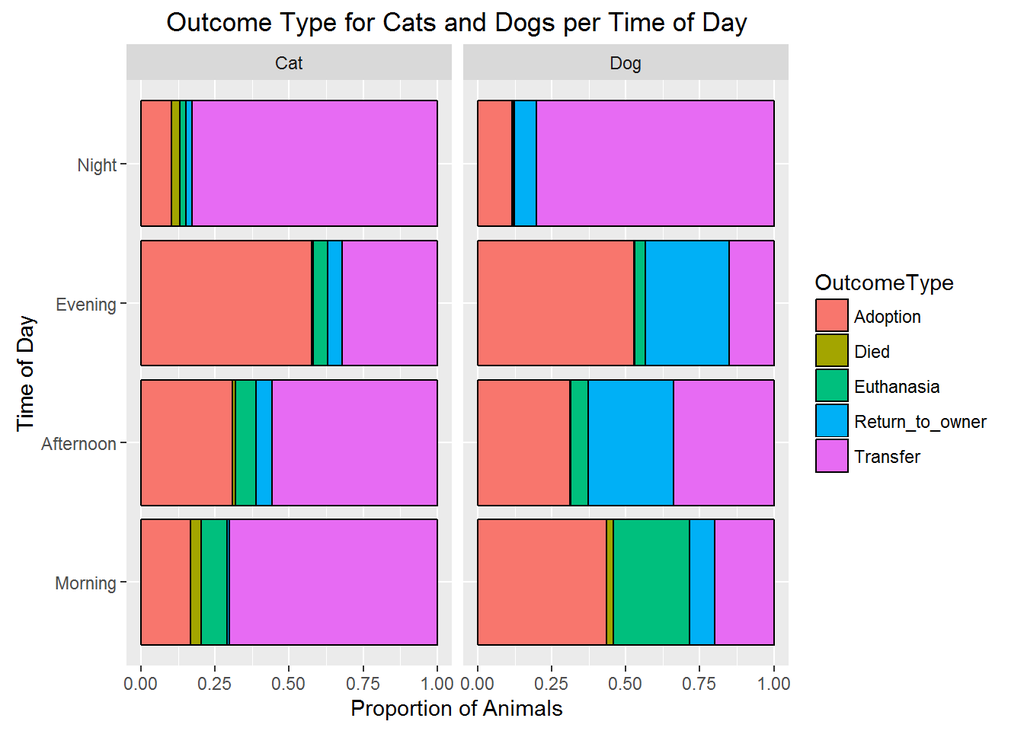

```r
#plot the data
ggplot(full[full$data=="train",],aes(x=timeofday,fill=OutcomeType))+
      geom_bar(position="fill",color="black")+
      coord_flip()+
      facet_grid(.~AnimalType)+
      labs(y="Proportion of Animals",x="Time of Day",title="Outcome Type for Cats and Dogs per Time of Day")
```

Ok, so there’s definitely something going on between time of day and `OutcomeType`. Immediately, a few things stand out to me, like the fact that both cats and dogs are much more likely to get transfered than other outcomes at night and how both cats and dogs are more likely to get adopted during the evening (as opposed to other outcomes). Also, it seems that the majority of dog euthanizations happen in the morning, cats are more likely to die during the morning or night time, and dogs are more likely to die in the morning. I find it odd that animal death isn’t evenly distributed among the four time periods, since I feel like the time of day being morning doesn’t actually make cats and dogs more likely to suddenly just die. Let’s bring up a table of `timeofday` vs. `OutcomeType` for both cats and dogs to make sure what we’re seeing in the plot is correct.

```r
#Cat outcomes per time of day
with(full[full$AnimalType=="Cat",],table(timeofday,OutcomeType))
```

```
##            OutcomeType
## timeofday   Adoption Died Euthanasia Return_to_owner Transfer
##   Morning        271   59        140              14     1142
##   Afternoon     1610   58        366             284     2918
##   Evening       2376   26        201             199     1325
##   Night           15    4          3               3      120
```

```r
#Dog outcomes per time of day
with(full[full$AnimalType=="Dog",],table(timeofday,OutcomeType))
```

```
##            OutcomeType
## timeofday   Adoption Died Euthanasia Return_to_owner Transfer
##   Morning        209   11        124              41       96
##   Afternoon     2256   23        434            2096     2460
##   Evening       4002   15        286            2130     1154
##   Night           30    1          1              19      207
```

Looking at the tables, we can see that animal death is actually pretty evenly distributed throughout the day for both cats and dogs, and the majority of euthanizations actually happen during the afternoon for both animals. Does this mean that our plot is incorrect? No, it just means that we have to careful with how we interpret it. What the plot is really saying about animal deaths is that given an animal outcome happening in the morning, the odds of that animal outcome being `Died` as opposed to some other outcome is greater than during the rest of the day. The plot is *not* saying that the majority of cat and dog deaths happen during the morning. The same thing can be said for dog euthanizations; the majority of them do not take place during the morning, but given the fact that an animal has an outcome during the morning and that that animal is a dog, the odds of that outcome being euthanasia are higher during the morning then at other times.

Taking all of this into account, the `timeofday` variable we just created does seem to have some explanatory power over `OutcomeType`, so we’ll include it in our final model. Let’s move on to creating our seasonal variable.

#### Season

Here I’ll create our seasonal variable, `season`, to represent Spring (March-May), Summer (June-August), Fall (September-November), and Winter (December-February). Shout out to Wikipedia for telling me which months are in which seasons.

```r
#creating our seasonal variable
full$season<-ifelse(month(full$DateTime) %in% c(3,4,5),"Spring",
                  ifelse(month(full$DateTime) %in% c(6,7,8),"Summer",
                  ifelse(month(full$DateTime) %in% c(9,10,11),"Fall","Winter")))
full$season<-factor(full$season,levels=c("Spring","Summer","Fall","Winter"))
summary(full$season)
```

```
## Spring Summer   Fall Winter
##   7514  10011  10829   9831
```

Alright, now we have a variable to distinguish between each of the four seasons. Let’s plot it out and see if anything is going on in the data that helps explain animals’ outcomes.

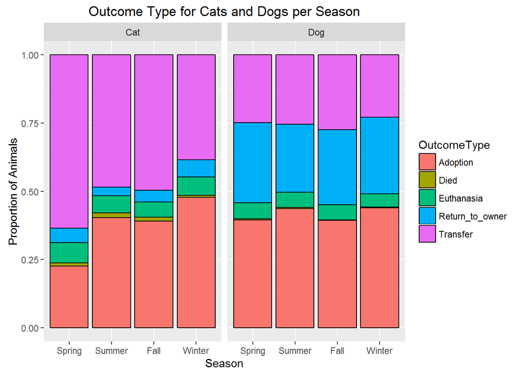

```r
#plotting out the seasonal variable
ggplot(full[full$data=="train",],aes(x=season,fill=OutcomeType))+
      geom_bar(position="fill",color="black")+
      facet_grid(.~AnimalType)+
      labs(x="Season",y="Proportion of Animals",title="Outcome Type for Cats and Dogs per Season")
```

Well, there definitely appears to be something going on here, even if it isn’t much. The cat side of the graph definitely has some noticeable differences in outcome probabilities, with cats being less likely to be adopted and more likely to be transferred in the spring. Also, it looks like that during the winter time cats are more likely to be adopted and less likely to be transferred relative to other seasons. There are also subtle differences between probabilities of death, euthanasia, and being returned to their owners. Looking at the dog portion of the graph though is pretty uninteresting; not a lot appears to be changing from one month to the next.

Let’s make a variable that distinguishes between each individual month as opposed to just the four seasons and see if it offers more insight into how animal outcomes are determined.

```r
#creating our 'month' variable
full$month<-month(full$DateTime,label = TRUE)
summary(full$month)
```

```
##  Jan  Feb  Mar  Apr  May  Jun  Jul  Aug  Sep  Oct  Nov  Dec
## 3336 2679 2115 2339 3060 3299 3596 3116 2898 4139 3792 3816
```

Ok, looks like that’s done. Now let’s plot out the data and see if there’s anything going on between month of the year and animal outcome.

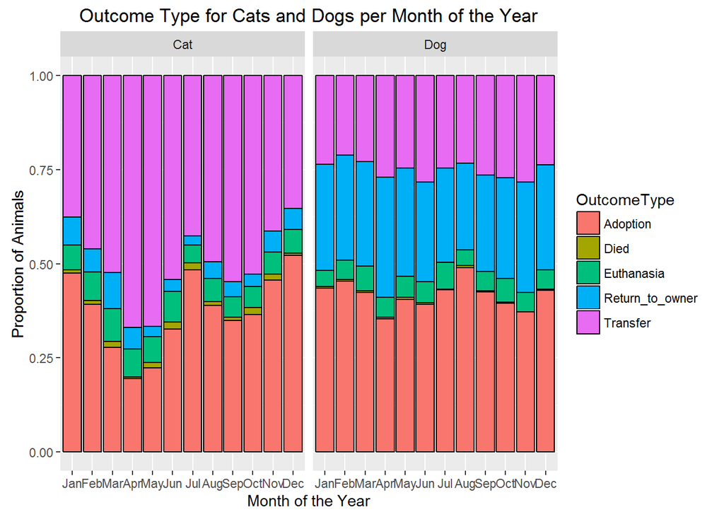

```r
#plotting 'month' vs. 'OutcomeType'
ggplot(full[full$data=="train",],aes(x=month,fill=OutcomeType))+
      geom_bar(position="fill",color="black")+
      facet_grid(.~AnimalType)+
      labs(x="Month of the Year",y="Proportion of Animals",title="Outcome Type for Cats and Dogs per Month of the Year")
```

Wow, well look at that! There’s definitely a lot of variance in outcome type probabilities from one month to the next for cats and some variance for dogs. We even managed to capture the fact that cats are less likely to be returned to their owners in July as opposed to other months (as we observed earlier on in our exploration). The relationship between month of the year and animal outcome doesn’t appear to be linear, so keeping our `month` variable discrete is probably the best course of action (as opposed to creating a continuous variable that measured days since the beginning of the year, which would be better if the relationship *was* linear). There’s definitely more going on for cats than dogs based on month of the year, but I’m sure that our model will benefit from the inclusion of this variable. As a result, **I will be including** `month` **in my final model**.

#### Day of Week and Weekday/Weekend

In this section I’ll try two different approaches to capture the day of the week. First, I’ll create a variable that distinguishes between the day of the week falling on either a weekday or a weekend. Then, I’ll create a variable that distinguishes between all 7 days of the week. The idea here is that maybe adoptions happen more often on weekends rather than during the week, or maybe adoptions happen more often on Fridays rather than other days. I’ll make the two variables below and let the data do the talking, but only one will be included in the final model (if any) since they both aim to capture the same relationship in the data.

```r
#creating our weekday/weekend variable
full$weekday<-ifelse(wday(full$DateTime) %in% c(2,3,4,5,6),"Weekday","Weekend")
full$weekday<-factor(full$weekday,levels=c("Weekday","Weekend"))

#creating our day of the week variable
full$dayofweek<-wday(full$DateTime,label=TRUE)
full$dayofweek<-factor(full$dayofweek,levels=c("Mon","Tues","Wed","Thurs","Fri","Sat","Sun"))

summary(full$weekday)
```

```
## Weekday Weekend
##   25832   12353
```

```r
summary(full$dayofweek)
```

```
##   Mon  Tues   Wed Thurs   Fri   Sat   Sun
##  5420  5515  4990  4822  5085  6186  6167
```

Alright, now that we’ve created our two variables, let’s see what shows up in the data when we plot each of these two variables vs. the response variable, `OutcomeType`. Let’s start with `weekday`.

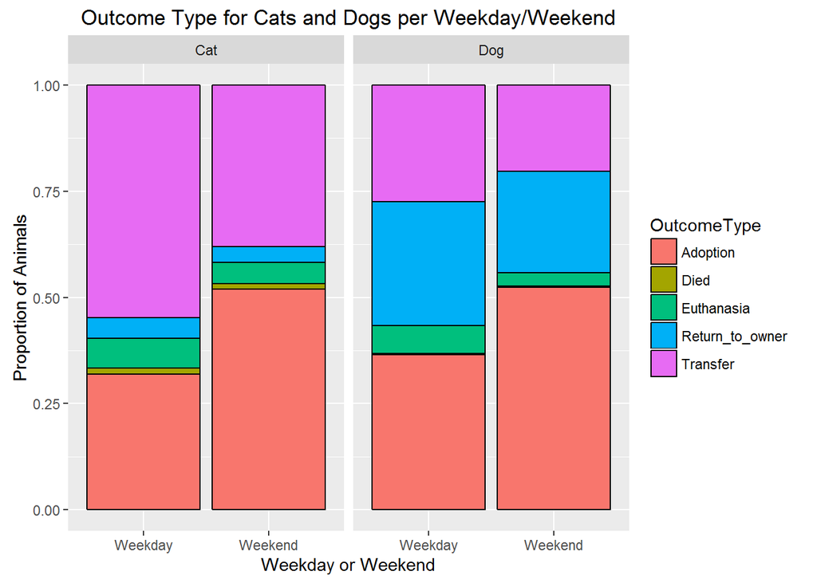

```r
#plotting out our weekday variable
ggplot(full[full$data=="train",],aes(x=weekday,fill=OutcomeType))+
      geom_bar(position="fill",color="black")+
      facet_grid(.~AnimalType)+
      labs(x="Weekday or Weekend",y="Proportion of Animals",title="Outcome Type for Cats and Dogs per Weekday/Weekend")
```

Cool, it looks like `OutcomeType` is indeed distributed differently on weekdays versus weekends. The plot tells us that both cats and dogs are more likely to get adopted and less likely to be transfered on weekends than they are on weekdays. It would make sense that adoptions are more likely to happen on weekends rather than weekdays, since families probably go out to animal shelters together on weekends to adopt animals. Perhaps animal transfers are less likely to occur on weekends since there are less animal shelter employees who are in charge of transfers working on weekends. The other outcomes don’t appear to change much, which is to be expected.

Let’s see how well our variable `dayofweek` performs.

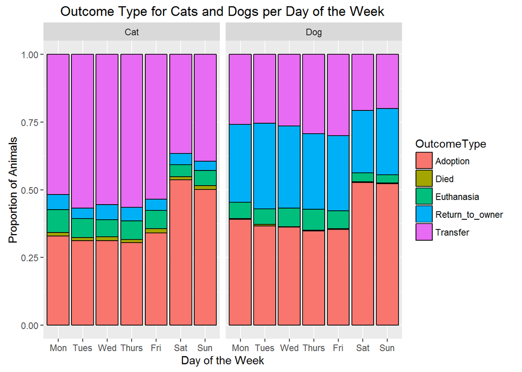

```r
#plotting out 'dayofweek' vs. 'OutcomeType'
ggplot(full[full$data=="train",],aes(x=dayofweek,fill=OutcomeType))+
      geom_bar(position="fill",color="black")+
      facet_grid(.~AnimalType)+
      labs(x="Day of the Week",y="Proportion of Animals",title="Outcome Type for Cats and Dogs per Day of the Week")
```

Looking at the graph, the variable `dayofweek` doesn’t seem to explain *too* much more about `OutcomeType` than the variable `weekday`, but there do appear to be small differences in the probability of certain outcome types occurring given the specific day of the week. These small differences could help our random forest model perform better, even if only by a small amount, so I will use the `dayofweek` variable for the final model and exclude the variable `weekday`. Like I mentioned in my conclusionary discussion on the variable `SexuponOutcome`, the random forest model is capable of making its own statistically informed decisions about how certain predictors’ categories affect the response variable, so using the variable `weekday` instead of `dayofweek` would offer less information to the `randomForest` algorithm and thus hinder its performance. In other words, having a user manually create bins for a variable just ends up making the final random forest model poorer since the `randomForest` algorithm has been designed to do this task itself.

#### Concluding Thoughts for DateTime

Well, that just about wraps it up for feature engineering with our original `DateTime` variable. Lots of different ideas, lots of cool stuff. Took a decent amount of time and coding, but we’re finally through it all. Here are the important points to take note of before moving on:

- `DateTime` on its own **does not** have any explanatory power over `OutcomeType`
- Our variable `timeofday` for capturing whether or not the animal outcome occurs during morning, afternoon, evening, or night time **does** have explanatory power over `OutcomeType` and **will be included in the final model**
- Our variables `season` and `month` both aim to capture the changes in outcome probabilities during different times of the year, but `month` captures more of the variance in outcome probabilities than `season`. As a result, **only** `month` **will be included in the final model**
- Our variables `weekday` and `dayofweek` for differentiating between weekday/weekend and day of the week both have explanatory power over `OutcomeType`, but `dayofweek` offers a little bit more information thatn `weekday`. As such, **only** `dayofweek` **will be included in the final model**

### SexuponOutcome

Let’s take a look at our next variable, `SexuponOutcome`.

```r
summary(full$SexuponOutcome)
```

```
##               Intact Female   Intact Male Neutered Male Spayed Female       Unknown
##             1          5004          4985         14014         12633          1548
```

At a glance, we see that there are a bunch of intact male/female animals, neutered/spayed male/female animals, and some unknown animals. There’s also one animal with a blank for its sex. If having a blank for your sex isn’t “Unknown” then I don’t know what is, so I’m going to go ahead and change that animal’s sex to `Unknown`.

```r
#correcting blank observation
full$SexuponOutcome[full$SexuponOutcome==""]<-"Unknown"
full$SexuponOutcome<-factor(full$SexuponOutcome)
summary(full$SexuponOutcome)
```

```
## Intact Female   Intact Male Neutered Male Spayed Female       Unknown
##          5004          4985         14014         12633          1549
```

Alright, we fixed that issue. Now let’s get on to the critical thinking part where we try to think up how an animal’s sex can affect its outcome. My hunch is that neutered and spayed animals are probably in higher demand for adoption, since they are less of a hassle to maintain, and as a result will have different likelihoods for the different animal outcomes than intact males and females. Let’s make a new variable to distinguish between intact and neutered/spayed animals. We’ll keep the `Unknown` animals marked as `Unknown`.

```r
#creating our new variable 'intact'
full$intact<-ifelse(grepl("Intact",full$SexuponOutcome),"Intact",
                    ifelse(grepl("Unknown",full$SexuponOutcome),"Unknown","Neutered/Spayed"))
full$intact<-factor(full$intact,levels=c("Neutered/Spayed","Intact","Unknown"))
summary(full$intact)
```

```
## Neutered/Spayed          Intact         Unknown
##           26647            9989            1549
```

Time to let the data do the talking. Let’s plot out our new variable `intact` vs. `OutcomeType`. Credit to Megan Risdal for inspiring me to use this type of plot.

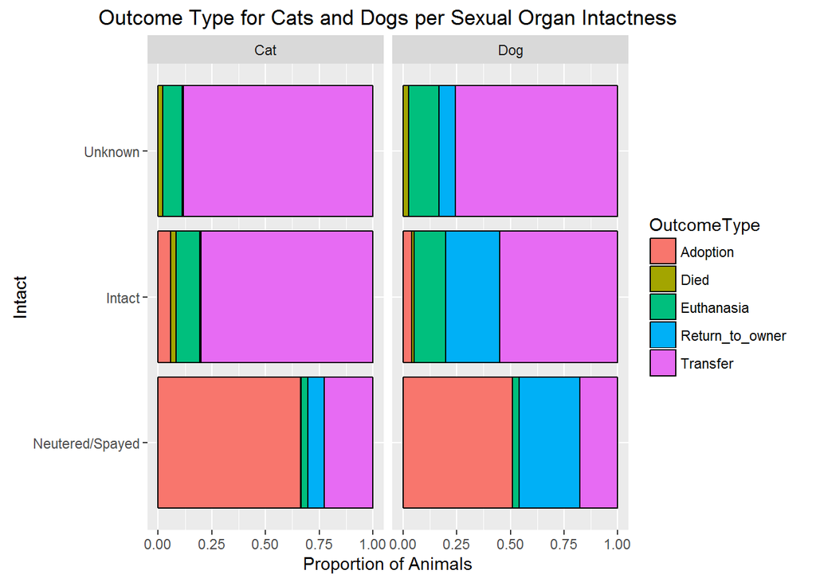

```r
#plotting out intact
ggplot(full[full$data=="train",],aes(x=intact,fill=OutcomeType))+
      geom_bar(position="fill",color="black")+
      facet_grid(.~AnimalType)+
      coord_flip()+
      labs(x="Intact",y="Proportion of Animals",title="Outcome Type for Cats and Dogs per Sexual Organ Intactness")
```

Just as I had expected, animals that have been neutered or spayed are much more likely to be adopted than animals that are still intact (or animals whose sexual intactness is “Unknown”… still not sure what that entails but it doesn’t sound fun or cool). It also looks like animals whose sexual intactness is unknown are actually not adopted at all; lets bring up a table of the data for `intact` versus `OutcomeType` and see if this is true.

```r
#making a table of intact vs. OutcomeType
with(full[full$data=="train",],table(intact,OutcomeType))
```

```
##                  OutcomeType
## intact            Adoption  Died Euthanasia Return_to_owner Transfer
##   Neutered/Spayed    10408    37        576            3995     3583
##   Intact               361   135        878             778     4884
##   Unknown                0    25        101              13      955
```

It looks like I’m right; animals whose sexual intactness is unknown have a **0% chance of adoption**. Pretty cool. Hopefully our random forest model will pick up on this.

Looking back at our plot, there are a few other things that stand out to us. Animals who have not been neutered or spayed are much more likely to be transferred, euthanized, or die. The increased likelihood of being transferred makes sense, since the animals may all be transferred to some other facility in order to get spayed/neutered. The increased likelihood of being euthanized or dying also makes sense, since an animal having their sexual organs intact is probably a good indicator that their owner couldn’t afford to take them to the vet to get the procedure done; if their owner couldn’t afford that (or couldn’t be bothered to take the animal to the vet), then it’s likely that the owner also couldn’t afford other medical procedures, leaving their animal with other possible medical complications that would ultimately result in their death or euthanization once they reach the animal shelters. Another possible explanation is that animals that haven’t been neutered or spayed are so much less likely to get adopted that they end up staying at animal shelters until they die of old age. Interesting stuff once again.

In addition to creating our variable `intact`, we can also create a variable to distinguish between female and male animals. Let’s create that variable now.

```r
#creating variable for 'sex'
full$sex<-ifelse(grepl("Male",full$SexuponOutcome),"Male",
                 ifelse(grepl("Female",full$SexuponOutcome),"Female","Unknown"))
full$sex<-factor(full$sex,levels=c("Male","Female","Unknown"))
summary(full$sex)
```

```
##    Male  Female Unknown
##   18999   17637    1549
```

We can see that there’s some overlap between `intact` and `sex` in regards to the “Unknown” category, but let’s plot out `sex` vs. `OutcomeType` for cats and dogs and see what’s going on in the data. I will exclude animals that have a sex of `Unknown` in order to focus on the relationship between an animal being male/female and its outcome.

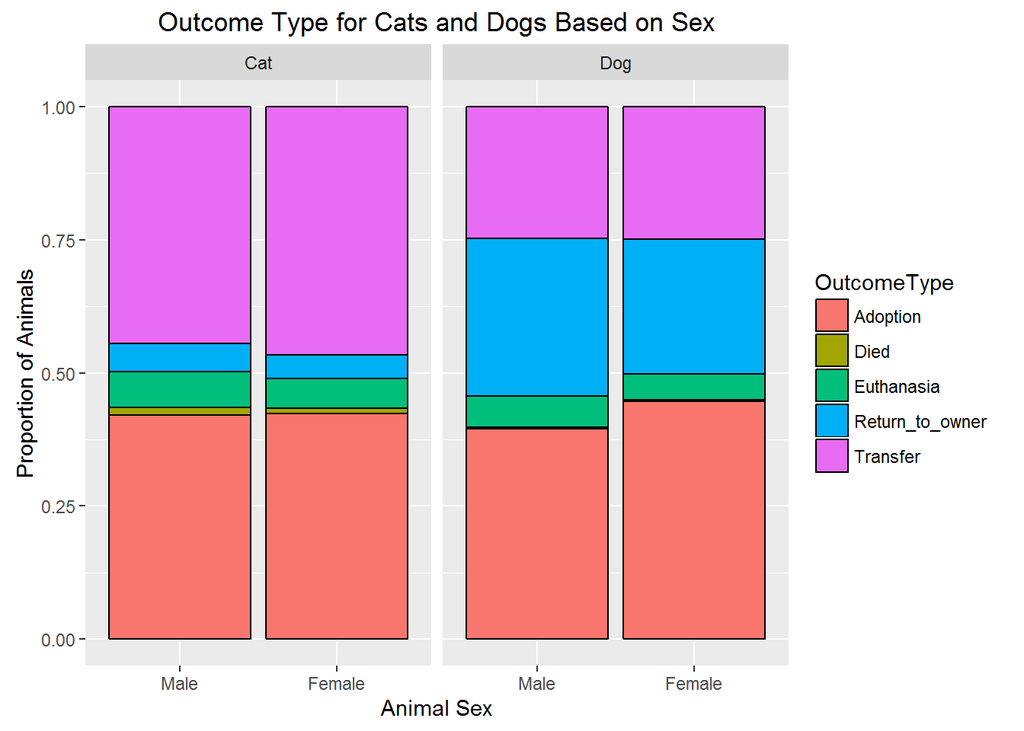

```r
#plotting 'sex' vs. 'OutcomeType' for cats and dogs
ggplot(full[full$data=="train"&full$sex!="Unknown",],aes(x=sex,fill=OutcomeType))+
      geom_bar(position="fill",color="black")+
      facet_grid(.~AnimalType)+
      labs(x="Animal Sex",y="Proportion of Animals",title="Outcome Type for Cats and Dogs Based on Sex")
```

Well, there doesn’t appear to be a whole lot of a difference between male and female animals in regards to their outcomes. The most noticeable differences are how femal cats are more likely to be transfered and less likely to die, and female dogs are more likely to be adopted but less likely to be returned to their owners.

Given the relationships in the data we just explored, I have decided that I will use the original `SexuponOutcome` variable in my final model (with the one missing value replaced). Sexual organ intactness definitely helps explain different animals’ outcomes, and animal gender provides some small pointers in the right direction as well. Given the nature of the `randomForest` model, creating artificial bins to differentiate between the different categories of `SexuponOutcome` will only hinder model performance, and provided the model the original `SexuponOutcome` will allow it to come to its own statistically informed conclusions about animal outcomes based on both sexual intactness and animal gender (versus being fed new variables that have drawn distinctions between `SexuponOutcome` categories manually and not through statistical procedures).

In summary, I will be using the original variable `SexuponOutcome` in my final model as **it does explain variance in animal outcomes**. I will **not** be using my homemade variables `intact` and `sex`; their main purpose was to help explain the relationship between animal gender/sexual intactness and outcome type visually.

### AgeuponOutcome

Let’s take a look at our next variable, `AgeuponOutcome`.

```r
summary(full$AgeuponOutcome)
```

```
##             0 years     1 day   1 month    1 week   1 weeks    1 year 10 months  10 years 11 months  11 years
##        24        35        84      1782       220       247      5737       653       598       241       174
##  12 years  13 years  14 years  15 years  16 years  17 years  18 years  19 years    2 days  2 months   2 weeks
##       330       214       143       115        45        30        12         5       139      4929       727
##   2 years  20 years  22 years    3 days  3 months   3 weeks   3 years    4 days  4 months   4 weeks   4 years
##      5383         7         2       148      1788       950      2589        78      1283       465      1506
##    5 days  5 months   5 weeks   5 years    6 days  6 months   6 years  7 months   7 years  8 months   8 years
##        38       929        15      1406        80       835       927       455       769       569       772
##  9 months   9 years
##       313       394
```

So our age variable right now is not very useful to us. Representing something like age (which should be a continuous variable) as a 46-level categorical variable really prevents us from measuring and observing the true relationship between age and animal outcome. On top of that, the factor levels aren’t even in chronological order; if we look closely at the output above, we can see that all the categories with “1” as the first character are grouped together, then all the categories with a “2”, and so on. At a minimum, this makes the task of creating a high quality visualization of age vs. outcome very challenging, as we’ll have to reorder all of the levels by hand so that they are in order.

Instead of fumbling around with factor levels only to still end up with a mediocre predictor variable, let’s go ahead and make a continuous version of our `AgeuponOutcome` variable. Another shoutout to Megan Risdal for the inspiration on how to tackle this problem.

```r
#first, extract the age number
agenum<-as.numeric(sapply(full$AgeuponOutcome,function(x) strsplit(as.character(x)," ")[[1]][1]))

#next, extract unit of time
ageunit<-sapply(full$AgeuponOutcome,function(x) strsplit(as.character(x)," ")[[1]][2])
unique(ageunit)
```

```
## [1] "year"   "years"  "weeks"  "month"  "months" "days"   "week"   "day"    NA
```

```r
#we need to turn entries like "day" and "days" into the same unit
ageunit<-gsub("s","",ageunit)
unique(ageunit)
```

```
## [1] "year"  "week"  "month" "day"   NA
```

```r
#all fixed. now we need to turn each unit of time into a numeric multiplier
agemult<-ifelse(ageunit=="day",1,
            ifelse(ageunit=="week",7,
            ifelse(ageunit=="month",30,
            ifelse(ageunit=="year",365,NA))))

#now to create our final continuous age variable
full$agecont<-agenum*agemult
summary(full$agecont)
```

```
##    Min. 1st Qu.  Median    Mean 3rd Qu.    Max.    NA's
##     0.0    60.0   365.0   788.6  1095.0  8030.0      24
```

Ok, looks like we have our new continuous age variable. Only one problem remains now, and that’s the presence of 24 missing values. Before we go about replacing those values, let’s just take a look at all the observations where `agecont` is NA to see if they have anything in common.

```r
full[is.na(full$agecont),]
```

```
##       AnimalID Name            DateTime OutcomeType OutcomeSubtype AnimalType SexuponOutcome AgeuponOutcome
## 2481   A720674      2016-02-16 10:17:00    Transfer           SCRP        Cat    Intact Male
## 2913   A720973      2016-02-18 19:07:00    Transfer           SCRP        Cat        Unknown
## 3767   A720820      2016-02-16 18:55:00    Transfer           SCRP        Cat  Intact Female
## 3876   A721076      2016-02-20 16:37:00  Euthanasia      Suffering        Dog    Intact Male
## 4499   A720422      2016-02-09 19:43:00    Transfer           SCRP        Cat  Intact Female
## 5138   A720697      2016-02-16 10:17:00    Transfer           SCRP        Cat  Spayed Female
## 5692   A720640      2016-02-16 10:17:00    Transfer           SCRP        Cat        Unknown
## 7006   A720636      2016-02-16 10:17:00    Transfer           SCRP        Cat        Unknown
## 8421   A720701      2016-02-16 10:16:00    Transfer           SCRP        Cat    Intact Male
## 17465  A720782      2016-02-16 18:55:00    Transfer           SCRP        Cat  Intact Female
## 18491  A720780      2016-02-16 18:54:00    Transfer           SCRP        Cat  Intact Female
## 19928  A720653      2016-02-16 10:16:00    Transfer           SCRP        Cat  Intact Female
## 21524  A720652      2016-02-16 10:16:00    Transfer           SCRP        Cat    Intact Male
## 22381  A720534      2016-02-11 19:26:00    Transfer           SCRP        Cat  Intact Female
```

[output cut: 60 more lines]

Anyways, let’s go ahead and fit a `randomForest` regression model with `agecont` as the response variable and try to predict what the missing `agecont` values should be. `randomForest` doesn’t accept any data with `NA` values, so let’s make a quick data set out of our `full` data frame containing only the predictor variables we need for this model and excluding all `NA` observations.

```r
#preparing data set
not.NA<-full[!is.na(full$agecont),c(6,7,12,13,15,17,20)]

#loading package 'randomForest' for creating the random forest model
suppressMessages(require(randomForest))

#building randomForest model which will be used to predict NA 'agecont' values
age.mod<-randomForest(agecont~.,data=not.NA,ntree=600)

#analyzing model fit
age.mod
```

```
##
## Call:
##  randomForest(formula = agecont ~ ., data = not.NA, ntree = 600)
##                Type of random forest: regression
##                      Number of trees: 600
## No. of variables tried at each split: 2
##
##           Mean of squared residuals: 1029843
##                     % Var explained: 11.71
```

Well, let’s just say that this model won’t be wining us any Nobel Peace Prizes any time soon. Very, very poor fit, but it’s the best we can do given our data. I would’ve included `OutcomeType` in this model, since I’m absolutely certain that an animal’s outcome would help explain roughly what age it was, but 6 of the `NA` `agecont` values are in the test data set, which also have `NA` `OutcomeType` values; `randomForest` won’t accept any data that has `NA`s in it.

```r
#finding RMSE if every 'agecont' value was predicted to be 'median(agecont)'
med<-median(not.NA$agecont)
sqrt(mean((not.NA$agecont-med)^2))
```

```
## [1] 1160.125
```

Well, it’s clear now that just using the median value would, on average, result in an error of 1160.1247416 days when predicting the values of `agecont` (3.1784239 years), which is worse than how our `age.mod` model performed. Let’s just go ahead and use `age.mod` to predict the missing `agecont` values even though we know the model isn’t really the best in the world (24 missing values out of over 38,000 is pretty insignificant, so whatever error we have in predicting the missing values in `agecont` won’t have a big impact on our main model that will predict `OutcomeType`).

```r
#preparing data set
age.NA<-full[is.na(full$agecont),c(6,7,12,13,15,17,20)]

#predicting what the missing values should be
na.pred<-predict(age.mod,age.NA)

#swapping in our new predicted values
full$agecont[is.na(full$agecont)]<-na.pred

#checking to see we have no more NAs
summary(full$agecont)
```

```
##    Min. 1st Qu.  Median    Mean 3rd Qu.    Max.
##     0.0    60.0   365.0   788.5  1095.0  8030.0
```

```r
sum(is.na(full$agecont))
```

```
## [1] 0
```

Alright, looks like that’s that. Now that we’ve corrected all of the missing values for `agecont`, let’s plot out `agecont` versus `OutcomeType` and see what kind of a relationship is present in the data.

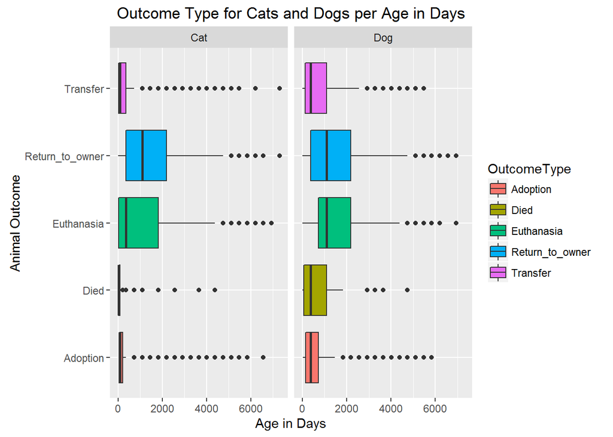

```r
#plotting agecont vs OutcomeType
ggplot(full[full$data=="train",],aes(x=OutcomeType,y=agecont,fill=OutcomeType))+
      geom_boxplot()+
      coord_flip()+
      facet_grid(.~AnimalType)+
      labs(x="Animal Outcome",y="Age in Days",title="Outcome Type for Cats and Dogs per Age in Days")
```

The plot is a little messy due to how spread out the age distributions are for each outcome type, but we can see that as age increases, animals are less likely to die, get adopted, or get transferred and are more likely to be euthanized or returned to their owner. I think that `agecont` does help explain some of the variance in `OutcomeType`, so it **will be included** in our final model.

### Breed

Let’s take a quick peek at what our `Breed` variable is in its raw state.

```r
#limiting summary so it doesn't take up a ton of space
summary(full$Breed)[1:40]
```

```
##             Domestic Shorthair Mix                       Pit Bull Mix            Chihuahua Shorthair Mix
##                              12587                               2776                               2498
##             Labrador Retriever Mix           Domestic Medium Hair Mix                German Shepherd Mix
##                               1949                               1217                                830
##              Domestic Longhair Mix                        Siamese Mix          Australian Cattle Dog Mix
##                                753                                562                                513
##                      Dachshund Mix               Miniature Poodle Mix                          Boxer Mix
##                                437                                336                                330
##                  Border Collie Mix            Australian Shepherd Mix                    Rat Terrier Mix
##                                324                                256                                226
##                      Catahoula Mix              Yorkshire Terrier Mix           Jack Russell Terrier Mix
##                                216                                213                                203
##            Miniature Schnauzer Mix                 Domestic Shorthair                 Siberian Husky Mix
##                                203                                194                                187
##             Chihuahua Longhair Mix                         Beagle Mix                     Rottweiler Mix
##                                186                                172                                162
##               American Bulldog Mix                       Shih Tzu Mix      Chihuahua Shorthair/Dachshund
##                                161                                152                                151
##                  Cairn Terrier Mix              Australian Kelpie Mix                 Great Pyrenees Mix
##                                150                                138                                137
##                  Staffordshire Mix American Staffordshire Terrier Mix                        Pointer Mix
##                                135                                129                                128
##                Chihuahua Shorthair                 Labrador Retriever        Labrador Retriever/Pit Bull
##                                125                                110                                108
##                    Plott Hound Mix                       Snowshoe Mix      Dachshund/Chihuahua Shorthair
##                                108                                105                                104
##                           Pit Bull
##                                101
```

```r
str(full$Breed)
```

```
##  Factor w/ 1678 levels "Abyssinian Mix",..: 1483 776 1294 776 1102 456 776 776 55 450 ...
```

Currently, our `Breed` variable is just a ton of different breed names thrown into one obnoxiously large factor variable. The main problem with this situation is that having so many different categories for breed doesn’t actually help inform us of the true relationship between `Breed` and `OutcomeType`, but another problem is that having more than 53 different levels in a single factor variable prevents it from being used by `randomForest`. Right now, `Breed` has 1678 different factor levels. That’s obscenely large and not at all useful to us.

So what can we do? Looking at the different entries in the `Breed` variable, we can see that there are a large number of breeds that have either the word “Mix” in them or a slash, indicating a cross between two breeds (or more). Why don’t we create a variable that distinguishes between dogs and cats that are a pure breed and ones that are a mix. Maybe this will help inform us of the relationship between animal breed and `OutcomeType`; I have a feeling it will most certainly be more useful than our current `Breed` variable.

```r
#creating new variable for pure/mix
full$mix<-ifelse(grepl("Mix|/",full$Breed),"Mix","Pure")
full$mix<-factor(full$mix,levels=c("Mix","Pure"))
summary(full$mix)
```

```
##   Mix  Pure
## 36199  1986
```

```r
prop.table(table(full$AnimalType,full$mix),1)
```

```
##
##              Mix       Pure
##   Cat 0.97765784 0.02234216
##   Dog 0.92674487 0.07325513
```

Ok, so we can see right off the bat that very few animals are pure relative to our entire sample of data. If we do the math, 2.2342161 percent of cats are purebred and 7.3255135 percent of dogs are purebred. That’s a pretty small amount. Let’s plot out the relationship between `mix` and `OutcomeType` and see if there’s anything going on in our new `mix` variable that helps explain animal outcomes.

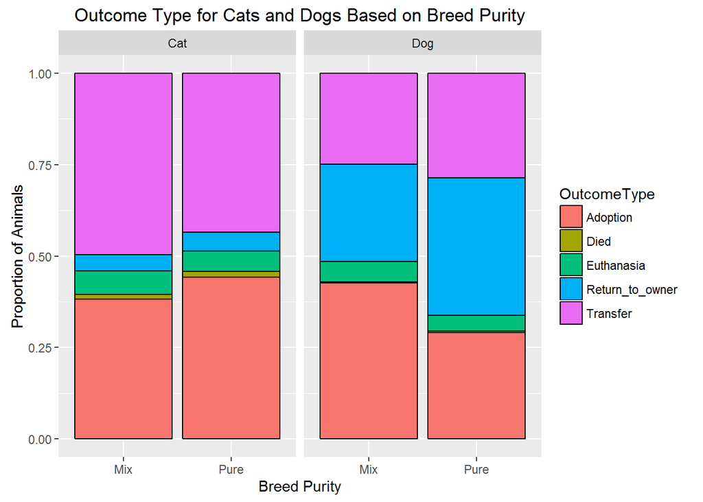

```r
#making plot
ggplot(full[full$data=="train",],aes(x=mix,fill=OutcomeType))+
      geom_bar(position="fill",color="black")+
      facet_grid(.~AnimalType)+
      labs(x="Breed Purity",y="Proportion of Animals",title="Outcome Type for Cats and Dogs Based on Breed Purity")
```

Well, the results aren’t super definitive, but there does appear to be some kind of relationship between `mix` and `OutcomeType`. Interestingly enough though, the relationship for cats is opposite that for dogs. It appears that purebred cats are slightly more likely to be adopted and slightly less likely to be transfered while purebred dogs are substantially less likely to be adopted and slightly more likely to be transfered. It also appears that purebred dogs are substantially more likely to be returned to their owners than mixed breed dogs.

I’ll include some tables to help us understand the relationsip between `mix` and `OutcomeType` numerically.

```r
#prepping data for dogs and cats
cat<-full[full$AnimalType=="Cat"&full$data=="train",]
dog<-full[full$AnimalType=="Dog"&full$data=="train",]

#creating tables
cat.mix<-prop.table(table(cat$mix,cat$OutcomeType),1)
dog.mix<-prop.table(table(dog$mix,dog$OutcomeType),1)

#adding titles so no one gets confused
names(dimnames(cat.mix))<-list("","Cats")
names(dimnames(dog.mix))<-list("","Dogs")

cat.mix
```

```
##       Cats
##          Adoption       Died Euthanasia Return_to_owner   Transfer
##   Mix  0.38231780 0.01314217 0.06396471      0.04475692 0.49581840
##   Pure 0.44268775 0.01581028 0.05533597      0.05138340 0.43478261
```

```r
dog.mix
```

```
##       Dogs
##           Adoption        Died  Euthanasia Return_to_owner    Transfer
##   Mix  0.426506191 0.003181850 0.054990662     0.266929515 0.248391783
##   Pure 0.290861160 0.003514938 0.043936731     0.375219684 0.286467487
```

Each table shows the proportion of mixbreed and purebreed animals in each outcome type for both cats and dogs. For example, we can see from these tables that purebreed dogs are 13% less likely to be adopted than mixbreed dogs and purebreed cats are 6% more likely to be adopted than mixbreed cats. For outcomes like death and euthanasia, there doesn’t appear to be a significant difference in likelihood between mixbreed and purebreed animals, but the other three outcomes (adoption, transfer, and returned to owner) do appear to have a noticeable difference in likelihood based on whether or not the animal is purebreed or mixbreed. The only catch is that some of these differences in likelihoods are opposite for cats and dogs.

As far as the quality of this variable goes (in regards to its explanatory power over `OutcomeType`), it isn’t anything revolutionary, but it does seem to offer some insight into how animal outcomes are determined, so **it will be included in our final model**. The one point of concern is that the relationship is opposite for cats and dogs, but I’m confident that our `randomForest` model will pick up on that.

#### Discussion on Possible Improvements for `Breed`

So is that it for `Breed`? Is it time to move on to our last variable, `Color`? Not yet. I had a few other ideas for how to use breed to predict `OutcomeType` that I wasn’t able to follow through with (due to a lack of knowledge on the physical and mental differences between different breeds), but I’d still like to discuss them to shed some light on how this data science challenge could be improved upon further (if someone took the time to gather up all the necessary information).

The `Breed` variable is really one of the most data-rich variables in this entire data set. If one had the knowledge and time, they could assign values to each animal such as height (determined by `Breed` and the animal’s age, given by `agecont`), emotional characteristics like aggression/friendliness/calmness (determined by `Breed`), weight (determined by `Breed`), any adverse health risks lurking down the line for each animal (again based on `Breed`), a dog’s main functionality (just a small dog to have fun with or a dog to accomplish certain tasks? also determined by `Breed`), and so on and so forth. There really are a ton of possibilities here, but it would take so long to gather all the necessary information and assign it to the 1678 different breeds of animals in this data set that it’s just not worth it at the moment. If somehow in some parallel universe type of situation predicting correct outcomes for each animal was literally the most important thing in the world, then I think this would be a great way to go about improving our model’s predictive accuracy. Again, however, it’s just not worth the time given the purpose of this project (mainly just to flex my data science knowledge and get some solid practice).

Another idea I had was to try to lump similar breeds together regardless of purity by extracting the first breed name from each animal (and then creating a factor variable with our shorter list of breeds), but this still resulted in too many different categories for one variable since there are a large number of breeds in this data set that have very few animals in them. I’ll show you what I came up with.

```r
#creating shortened breed name variable
full$breed2<-as.character(full$Breed)
full$breed2[grepl("/",full$breed2)]<-sapply(full$breed2[grepl("/",full$breed2)],function(x) strsplit(x,"/")[[1]][1])
full$breed2[grepl("Mix",full$breed2)]<-sapply(full$breed2[grepl("Mix",full$breed2)],function(x) strsplit(x," Mix")[[1]][1])
full$breed2<-factor(full$breed2)

#finding number of occurrences for each breed
breed.list<-full %>% group_by(breed2) %>% summarise(count=n()) %>% arrange(desc(count))
data.frame(breed.list)
```

```
##                                 breed2 count
## 1                   Domestic Shorthair 12786
## 2                             Pit Bull  3075
## 3                  Chihuahua Shorthair  3061
## 4                   Labrador Retriever  2728
## 5                 Domestic Medium Hair  1286
## 6                      German Shepherd  1180
## 7                    Domestic Longhair   785
## 8                Australian Cattle Dog   721
## 9                            Dachshund   710
## 10                             Siamese   615
## 11                               Boxer   492
## 12                       Border Collie   472
## 13                    Miniature Poodle   438
## 14                 Australian Shepherd   348
```

[output cut: 217 more lines]

Even our shortened list of breeds is far too long at 231 different breeds. If I had the relevant animal knowledge to group these different breeds into more general categories based on animal size, country of origin, or some other defining characteristic, I absolutely would. Unfortunately though, I do not have that knowledge, and this is where my data science journey with `Breed` comes to a halt.

There are also a few typos and missing values in some of the breed names, but correcting the typos (like “Oriental Sh” instead of “Oriental Shorthair”) and imputing the missing values (for the observations with “Unknown” as their breed) wouldn’t make a difference since we will only be using breed purity (our new variable `mix`) in our final model and will not keep the original `Breed` variable. Also, imputing the correct missing values for those 2 “Unknown” breed animals would be a nightmare, since there would be no good way to guess what the correct values are and fitting a model to predict the correct values would be impossible with so many options to consider.

Anyways, that just about wraps it up for our `Breed` variable, so let’s move on to our last variable, `Color`.

### Color

Like our variable `Breed`, we are faced with a similar situation with our `Color` variable in that there are far too many levels in this categorical variable.

```r
#limiting summary output so it doesn't take up a ton of space
summary(full$Color)[1:40]
```

```
##         Black/White               Black         Brown Tabby   Brown Tabby/White               White
##                4043                3265                2359                1333                1333
##         Brown/White        Orange Tabby           Tan/White            Tricolor          Blue/White
##                1257                1187                1114                1067                1004
##           Black/Tan         White/Black                 Tan               Brown         White/Brown
##                 986                 945                 910                 895                 771
##              Tortie              Calico                Blue Brown Brindle/White  Orange Tabby/White
##                 770                 710                 674                 661                 629
##         Black/Brown          Blue Tabby           White/Tan         Brown/Black              Torbie
##                 624                 616                 557                 493                 474
##           Red/White                 Red       Brown Brindle    Blue Tabby/White     Chocolate/White
##                 471                 470                 347                 336                 321
##         Cream Tabby               Sable              Yellow                Buff          Lynx Point
##                 309                 277                 275                 259                 255
##           Tan/Black               Cream           Chocolate          Seal Point          White/Blue
##                 254                 222                 205                 204                 184
```

```r
str(full$Color)
```

```
##  Factor w/ 411 levels "Agouti","Agouti/Brown Tabby",..: 147 185 98 48 312 41 71 118 284 360 ...
```

Not much explanation needed here, just way too many different levels for one categorical variable. In order to chop up `Color` into something useful, let’s extract the first word from each color, refactor the variable by these simpler colors, and see if we can narrow down the number of levels into something manageable.

```r
#creating shortened color variable
full$shortcolor<-sapply(as.character(full$Color), function(x) strsplit(x,"/| ")[[1]][1])
full$shortcolor<-factor(full$shortcolor)
summary(full$shortcolor)
```

```
##    Agouti   Apricot     Black      Blue     Brown      Buff    Calico Chocolate     Cream      Fawn     Flame
##         3        41      9544      3092      7641       358       795       675       754       295       121
##      Gold      Gray     Lilac     Liver      Lynx    Orange      Pink       Red     Ruddy     Sable      Seal
##       103       374        56        30       276      1882         2      1229         1       459       234
##    Silver       Tan    Torbie    Tortie  Tricolor     White    Yellow
##       132      2393       567       871      1131      4731       395
```

```r
str(full$shortcolor)
```

```
##  Factor w/ 29 levels "Agouti","Apricot",..: 5 9 4 4 24 3 4 5 19 28 ...
```

Some of these colors really are ridiculous, I wish whoever was in charge of coming up with animal colors would leave the poetic influences at home and just call them stuff like “red” or “orange” instead of “flame”. I mean come on guys, really.

Rant aside, our new color variable is in much better shape than our original one. We only have 29 different levels now instead of 400+, and I think I can even cut down a few more by combining some of the smaller, more unique colors. Agouti is a sort of brownish orangish mix, so we can put all the “agouti” colors into the “orange” category (I’m using some discretion here, I feel having tints of orange disqualifies the “agouti” animals from being considered brown). We can also put the “ruddy” colored animals into the “orange” group since that’s also fairly close to an orange color, and finally we can put the “pink” animals into the “lilac” group since that’s close enough as well.

```r
#reassigning color values
full$shortcolor[full$shortcolor=="Agouti"]<-"Orange"
full$shortcolor[full$shortcolor=="Ruddy"]<-"Orange"
full$shortcolor[full$shortcolor=="Pink"]<-"Lilac"
full$shortcolor<-factor(full$shortcolor)
summary(full$shortcolor)
```

```
##   Apricot     Black      Blue     Brown      Buff    Calico Chocolate     Cream      Fawn     Flame      Gold
##        41      9544      3092      7641       358       795       675       754       295       121       103
##      Gray     Lilac     Liver      Lynx    Orange       Red     Sable      Seal    Silver       Tan    Torbie
##       374        58        30       276      1886      1229       459       234       132      2393       567
##    Tortie  Tricolor     White    Yellow
##       871      1131      4731       395
```

```r
str(full$shortcolor)
```

```
##  Factor w/ 26 levels "Apricot","Black",..: 4 8 3 3 21 2 3 4 17 25 ...
```

Ok, that’s a little better. Now we’re just left with the challenge of either visualizing the relationship between `shortcolor` and `Outcometype` or coming up with some kind of table to inform us of how each animal color is distributed among the five different outcome types. Let’s try to make a bar chart similar to our other categorical visualizations.

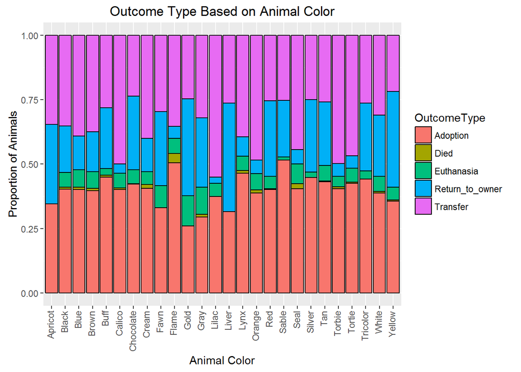

```r
#plotting 'shortcolor' vs. 'OutcomeType'
ggplot(full[full$data=="train",],aes(x=shortcolor,fill=OutcomeType))+
      geom_bar(position="fill",color="black")+
      labs(x="Animal Color",y="Proportion of Animals",title="Outcome Type Based on Animal Color")+
      theme(axis.text.x=element_text(angle=90,hjust=1,vjust=0.3))
```

There isn’t a ton of variation in outcomes from one color to the next, but there are a few color categories that definitely have different likelihoods for different outcomes. Let’s plot out the data with facets for cats and dogs to see if certain colors have different outcome probabilities for cats than they do for dogs.

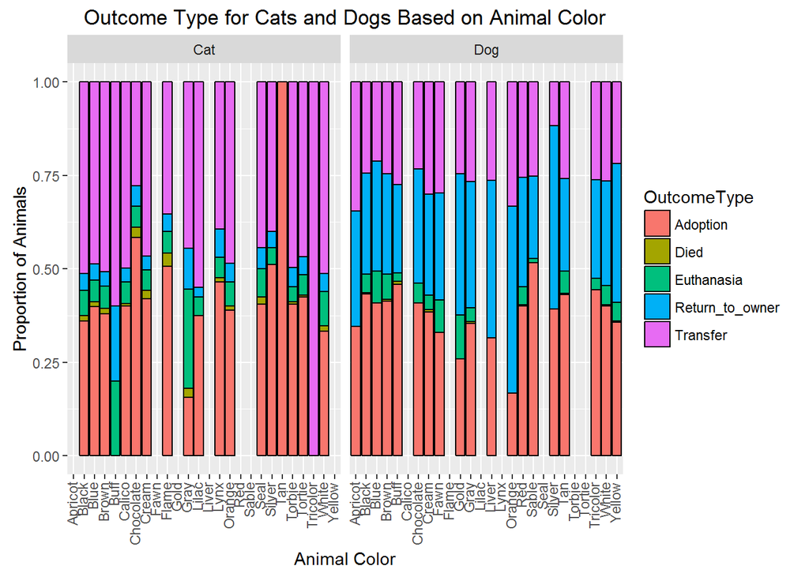

```r
#plotting 'shortcolor' vs. 'OutcomeType' for cats and dogs
ggplot(full[full$data=="train",],aes(x=shortcolor,fill=OutcomeType))+
      geom_bar(position="fill",color="black")+
      facet_grid(.~AnimalType)+
      labs(x="Animal Color",y="Proportion of Animals",title="Outcome Type for Cats and Dogs Based on Animal Color")+
      theme(axis.text.x= element_text(angle=90,hjust=1,vjust=0.3))
```

The plot is a little messy since some colors are only present for either cats or dogs (and not both), but it appears (at least on the surface) that there are still some interesting things going on with certain colors depending on the species of animal. One bar that stands out is tan colored cats. I originally thought that since this bar had a 100% adoption rate it meant something significant, but it turns out there’s only 1 tan colored cat so it actually means nothing.

This brings me to my next point. After realizing that a lot of the color categories with drastically different outcome probabilities had very few animals in them, I realized that the variance between each color category was not actually due to different colors resulting in different outcomes but instead caused by certain color categories having very few animals in them (and thus having skewed outcomes due to having a small sample size). This is a cause for concern since our model, when trained on our training data, may give tan colored cats a much higher chance of being adopted when in reality they are no more likely to be adopted than other colors (that’s just one hypothetical example). Scientifically speaking, there shouldn’t be any reason why certain colors would have drastically different outcomes than other colors. There may be small differences in outcome likelihoods from one color to another, but there shouldn’t be anything drastically different. For example, tan colored cats shouldn’t actually be far more likely to be adopted than cats with other color fur; we just don’t have enough observations for certain categories, which leads to certain colors having skewed outcomes. This will cause our model to have higher variance, since if it actually came to predict higher adoption rates for tan colored cats (as an example) it would be overfitted on the training data.

I made the following data frame to show the number of observations in each color category, split by dogs and cats.

```r
#data frame with number of animals per color
colors<-data.frame(full %>%
                         group_by(shortcolor,AnimalType) %>%
                         summarise(count=n()) %>%
                         arrange(desc(count)) %>%
                         rename(color=shortcolor,animal=AnimalType))
colors
```

```
##        color animal count
## 1      Black    Dog  5719
## 2      Brown    Dog  3915
## 3      White    Dog  3876
## 4      Black    Cat  3825
## 5      Brown    Cat  3726
## 6        Tan    Dog  2392
## 7       Blue    Cat  2027
## 8     Orange    Cat  1879
## 9        Red    Dog  1229
## 10  Tricolor    Dog  1129
## 11      Blue    Dog  1065
## 12    Tortie    Cat   871
## 13     White    Cat   855
## 14    Calico    Cat   795
```

[output cut: 27 more lines]

We can quickly see that there are a number of colors that, for either cats or dogs only, have very, very few occurences. Feeding these categories to our `randomForest` model would end up overfitting it on our training data; it would end up having higher variance due to assigning incorrectly high or low probabilities to certain animals in those low-observation color groups. This is something that should be avoided.

To illustrate how color groups with less observations have more variance (due to their samples not being accurate representations of the true population), I created the function below:

```r
colorcount<-function(cnt,under=FALSE){
      if(under==FALSE){
            data<-colors %>% filter(count>=cnt)
            titletext<-paste("Outcome Type for Cats and Dogs Based on Animal Color",
                             "\n Only Showing Colors w/",cnt,"or More Occurences")
      }
      if(under==TRUE){
            data<-colors %>% filter(count<=cnt)
            titletext<-paste("Outcome Type for Cats and Dogs Based on Animal Color",
                             "\n Only Showing Colors w/",cnt,"or Less Occurences")
      }
      if(!is.logical(under)){
            stop("argument 'under' must be logical",call.=FALSE)
      }
      newdata<-data.frame()
      for(i in 1:nrow(data)){
            colordata<-full %>% filter(shortcolor==data$color[i]&AnimalType==data$animal[i]&data=="train")
            newdata<-rbind(newdata,colordata)
      }
      ggplot(newdata,aes(x=shortcolor,fill=OutcomeType))+
            geom_bar(position="fill",color="black")+
            facet_grid(.~AnimalType)+
            labs(x="Animal Color",y="Proportion of Animals",title=titletext)+
            theme(axis.text.x=element_text(angle=90,hjust=1,vjust=0.3))+
            theme(plot.title=element_text(hjust=0.5))
}
```

This function first pulls out all the observations from the main data set that have colors with a specified minimum number of occurences and then plots the relationship between those color categories and `OutcomeType`. This is to filter out any color groups with a low number of occurences and thus a high variance. This function takes one input, `cnt`, which is the minimum count that color categories must have to be included in the plot. It uses the `colors` data frame created above to specify which colors to include (based on the colors that have a count greater than `cnt`). The argument `under=FALSE` tells the function to only choose color categories with `count>=cnt`; `under=TRUE` will tell the function to only choose color categories with `count<=cnt`. The two `if` statements at the beginning of the function select the appropriate data based on the argument `under` and also specify the correct title for the plot. Then, the data is gathered up and plotted.

Let’s give this function a test drive to explore how the variance in `OutcomeType` based on `shortcolor` changes as the number of observations in each color group increases. I will bring up our previous plot with all color categories included for cats and dogs as a starting point in our investigation.

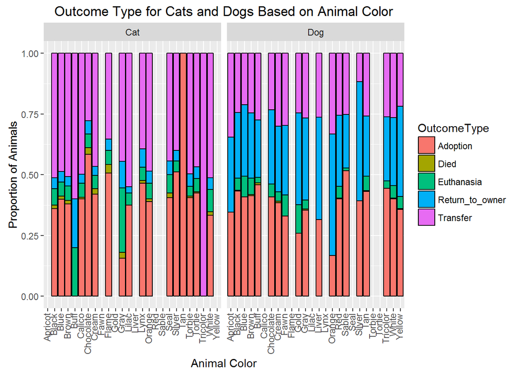

```r
#plotting 'shortcolor' vs. 'OutcomeType' for cats and dogs
ggplot(full[full$data=="train",],aes(x=shortcolor,fill=OutcomeType))+
      geom_bar(position="fill",color="black")+
      facet_grid(.~AnimalType)+
      labs(x="Animal Color",y="Proportion of Animals",title="Outcome Type for Cats and Dogs Based on Animal Color")+
      theme(axis.text.x= element_text(angle=90,hjust=1,vjust=0.3))
```

Let’s see what changes when we use only colors with `count>=100`.

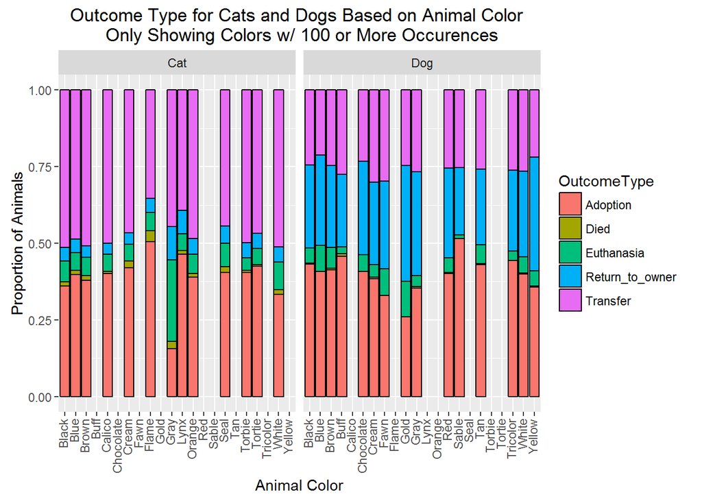

```r
colorcount(100)
```

We immediately see that a lot of the really wild/oddball color categories (the ones with very strange outcome distributions) have disappeared. The outcomes for cats are more similar to eachother and the same goes for dogs. This shows that the color categories with less than 100 observations have wildly high variance due to having an insufficiently large sample size and will throw off our model.

I’m going to move through `colorcount(250)`, `colorcount(500)`, and `colorcount(1000)` to show you how the variances in each color category decrease as the number of observations increases.

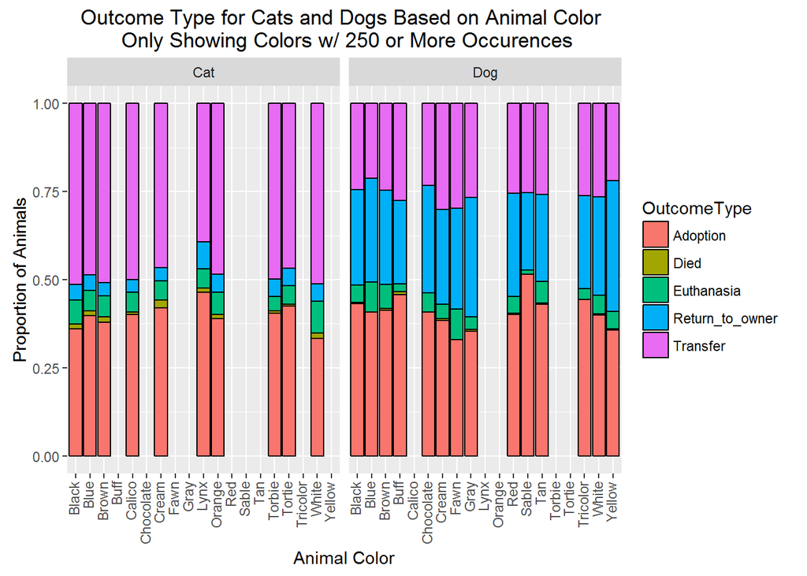

```r
colorcount(250)
```

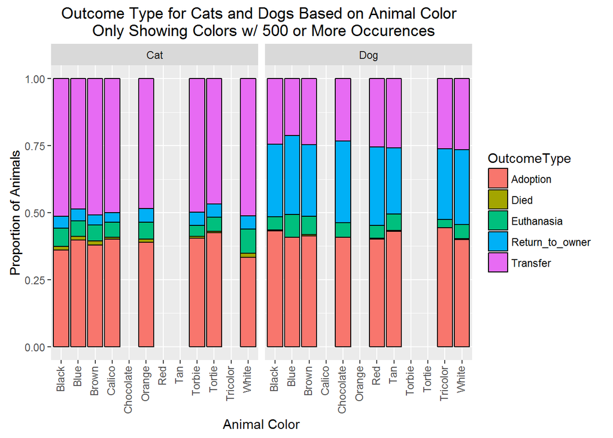

```r
colorcount(500)
```

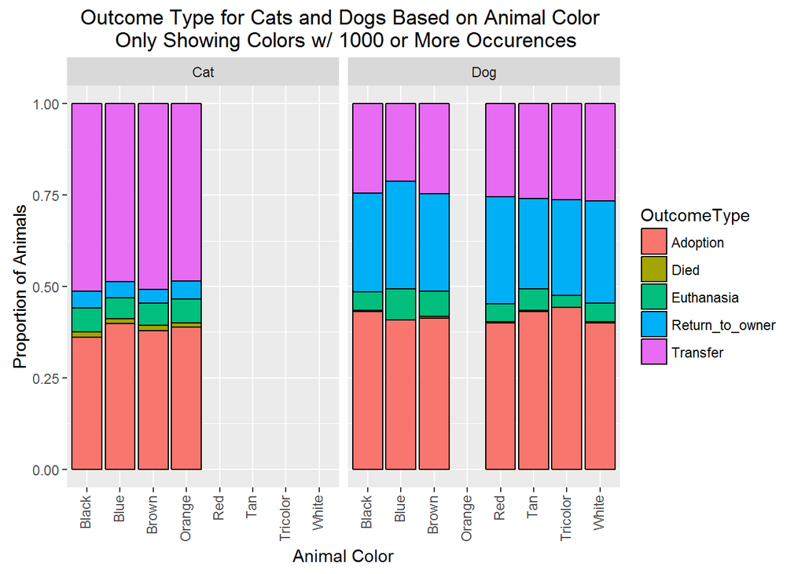

```r
colorcount(1000)
```

Starting at `count>=250`, we can see yet another improvement in terms of how variances become more similar to eachother. `colorcount(500)` shows that colors with at least 500 observations have even more similar outcome distributions, and `colorcount(1000)` shows that color categories with at least 1000 observations have near equal probability distributions. I’ll include `colorcount(2000)` and `colorcount(3000)` below just to drive the point home.

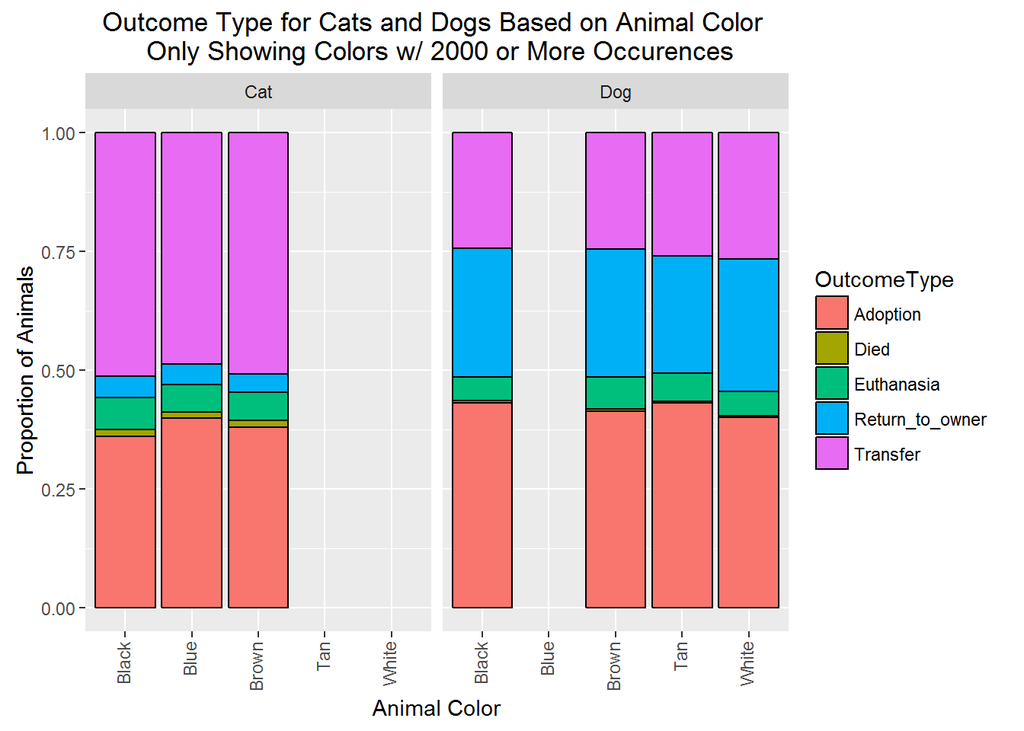

```r
colorcount(2000)
```

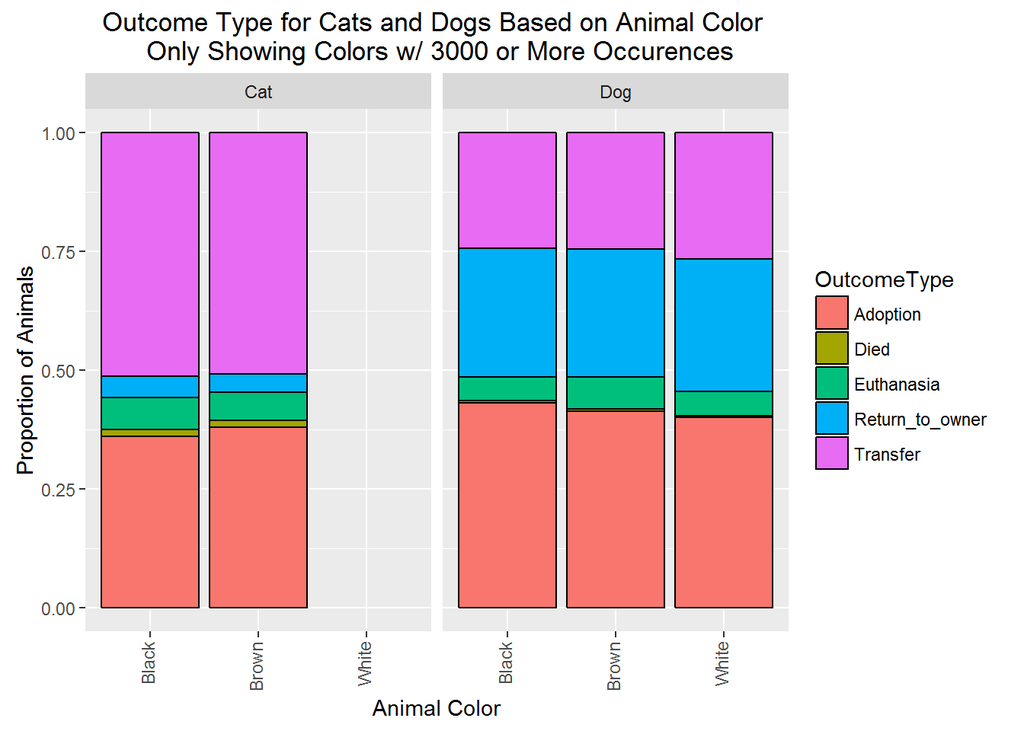

```r
colorcount(3000)
```

It is really easy to see that as the number of observations in a color category increases, the probability distribution for that category becomes more and more similar to other high-count categories. This evidence suggests that the probability distributions for the total population of each color category are actually equal to eachother, and that the variance we see in lower-count colors within our data set is caused by the sample sizes of those colors being too small and thus not indicative of the true relationship in the population.

To highlight the high variance between lower-count color groups, let’s use our `colorcount` function again but this time with `under=TRUE`. I will show `colorcount(250,under=TRUE)`, `colorcount(100,under=TRUE)`, and `colorcount(50,under=TRUE)`.

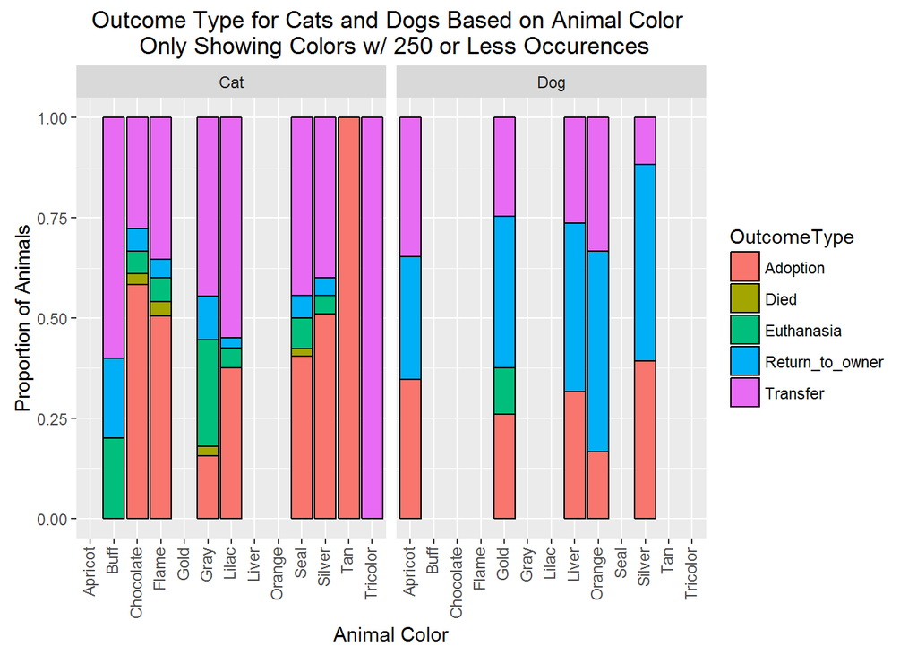

```r
colorcount(250,under=TRUE)
```

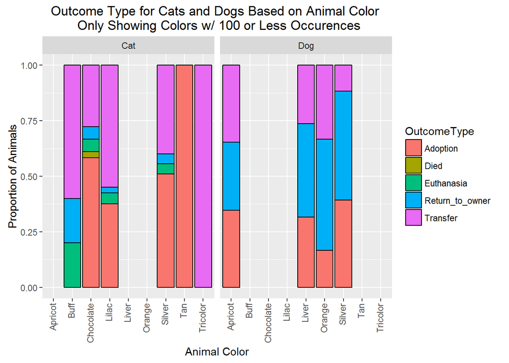

```r
colorcount(100,under=TRUE)
```

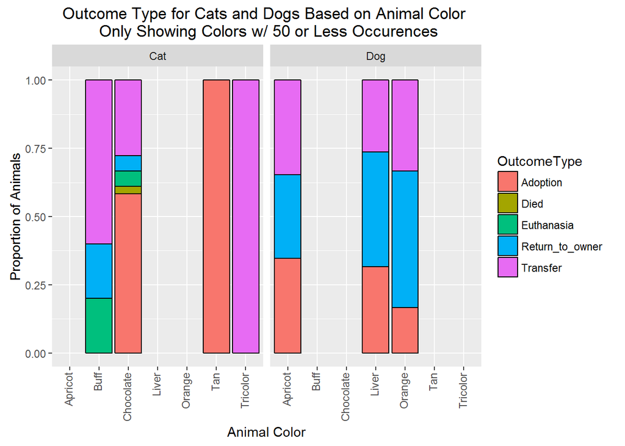

```r
colorcount(50,under=TRUE)
```

We can clearly see that as the number of observations per color group decreases, the variance in the outcome probabilities between classes increases. This is further evidence pointing to the fact that different colors don’t actually have different outcomes and only appear to due to a small sample size.

#### So What’s the Point?

The point is this: animal color does not actually help explain animal outcomes. We have seen that as the number of observations gets up towards 1000, the outcomes for each color group get more and more similar, which leads me to believe that the color groups with small sample sizes would also take on similar outcome probabilities if we had sufficient data. Are there differences between color categories in the probabilities of each outcome occuring? Sure, but they are very small differences. I’ll show this below:

```r
#these are the color categories we will be looking at
data<-colors %>% filter(count>=1000)
data
```

```
##       color animal count
## 1     Black    Dog  5719
## 2     Brown    Dog  3915
## 3     White    Dog  3876
## 4     Black    Cat  3825
## 5     Brown    Cat  3726
## 6       Tan    Dog  2392
## 7      Blue    Cat  2027
## 8    Orange    Cat  1879
## 9       Red    Dog  1229
## 10 Tricolor    Dog  1129
## 11     Blue    Dog  1065
```

```r
#now we assemble the data, similarly to how our 'colorcount' function does it
newdata<-data.frame()
for(i in 1:nrow(data)){
      colordata<-full %>% filter(shortcolor==data$color[i]&AnimalType==data$animal[i]&data=="train")
      newdata<-rbind(newdata,colordata)
}
cat.newdata<-newdata %>% filter(AnimalType=="Cat") %>% mutate(shortcolor=factor(shortcolor))
dog.newdata<-newdata %>% filter(AnimalType=="Dog") %>% mutate(shortcolor=factor(shortcolor))

#finally we make the tables for 'OutcomeType' based on cat and dog color categories
cat.table<-prop.table(table(cat.newdata$shortcolor,cat.newdata$OutcomeType),1)
dog.table<-prop.table(table(dog.newdata$shortcolor,dog.newdata$OutcomeType),1)

#adding titles to avoid confusion
names(dimnames(cat.table))<-list("","Cats")
names(dimnames(dog.table))<-list("","Dogs")

#printing tables
cat.table
```

```
##         Cats
##            Adoption       Died Euthanasia Return_to_owner   Transfer
##   Black  0.36032996 0.01462317 0.06674166      0.04499438 0.51331084
##   Blue   0.39857651 0.01352313 0.05765125      0.04341637 0.48683274
##   Brown  0.37961538 0.01423077 0.06038462      0.03807692 0.50769231
##   Orange 0.38955224 0.01119403 0.06417910      0.05000000 0.48507463
```

```r
dog.table
```

```
##           Dogs
##               Adoption        Died  Euthanasia Return_to_owner    Transfer
##   Black    0.431766776 0.003518472 0.050012566     0.270671023 0.244031164
##   Blue     0.408602151 0.000000000 0.084677419     0.294354839 0.212365591
##   Brown    0.413171450 0.004782929 0.068432671     0.267844003 0.245768948
##   Red      0.400688863 0.003444317 0.048220436     0.292766935 0.254879449
##   Tan      0.430962343 0.003586372 0.059772863     0.246861925 0.258816497
##   Tricolor 0.443609023 0.000000000 0.031328321     0.263157895 0.261904762
##   White    0.400145507 0.003273918 0.051655147     0.279738087 0.265187341
```

As we can see, the probability of each outcome occuring does vary between the different high-count color categories, but only very slightly. This goes for both cats and dogs. If we had enough samples for all the different color categories, then including this data would be helpful to our model (even if only offering the slightest of improvements in classification error rate), but alas we do not.

**The Bottom Line:** Including this variable in our model would likely increase the variance of our final model and decrease its predictive accuracy, as it would look at future data and come to certain conclusions about future animal outcomes based on that animal’s color that are simply untrue. This would be due to the model being trained on data that does not adequately represent the full populations of certain color groups. I will try running our model once with this variable included and once with it excluded to see if there’s a noticeable difference in test-set performance, but my hunch is that our model would be better off without this predictor in it.

## Building our Final Model

Well, it certainly took quite a while to make it here, but here we are at last. It has come time to bundle up our finalized predictors and build our `randomForest` model to predict the outcomes of future animals.

### Variables to be Included in the Model

Just to review, here are the variables we will be including in our model:

**Original Predictors to be Included:**

- `AnimalType` *whether or not the animal is a cat or a dog*
- `SexuponOutcome` *the animal’s sexual organ intactness (spayed/neutered, intact, or unknown) and its gender (male/female)*

**Custom Predictors to be Included:**

- `nameless` *whether or not the animal has a name*
- `timeofday` *during what time of day the animal’s outcome occurred*
- `dayofweek` *what day of the week the animal’s outcome occurred on*
- `month` *what month of the year the animal’s outcome occurred in*
- `agecont` *the animal’s age in days*
- `mix` *whether or not the animal a pure breed or mixed breed*
- `shortcolor` *the animal’s color* **(we will try one model with this variable and one without)**

### Making our Model

```r
#building random forest model with m=1
animal.1<-randomForest(OutcomeType~AnimalType+SexuponOutcome+nameless+timeofday+dayofweek+month+agecont+mix,
                        data=full[full$data=="train",],ntree=600,mtry=1)

#building random forest model with m=2
animal.2<-randomForest(OutcomeType~AnimalType+SexuponOutcome+nameless+timeofday+dayofweek+month+agecont+mix,
                        data=full[full$data=="train",],ntree=600,mtry=2)

#building random forest model with m=3
animal.3<-randomForest(OutcomeType~AnimalType+SexuponOutcome+nameless+timeofday+dayofweek+month+agecont+mix,
                        data=full[full$data=="train",],ntree=600,mtry=3)

#building random forest model with m=4
animal.4<-randomForest(OutcomeType~AnimalType+SexuponOutcome+nameless+timeofday+dayofweek+month+agecont+mix,
                        data=full[full$data=="train",],ntree=600,mtry=4)

#looking at all four models
animal.1
```

```
##
## Call:
##  randomForest(formula = OutcomeType ~ AnimalType + SexuponOutcome +      nameless + timeofday + dayofweek + month + agecont + mix,      data = full[full$data == "train", ], ntree = 600, mtry = 1)
##                Type of random forest: classification
##                      Number of trees: 600
## No. of variables tried at each split: 1
##
##         OOB estimate of  error rate: 38.16%
## Confusion matrix:
##                 Adoption Died Euthanasia Return_to_owner Transfer class.error
## Adoption           10341    0          0              96      332  0.03974371
## Died                  33    0          0               2      162  1.00000000
## Euthanasia           554    0          0              31      970  1.00000000
## Return_to_owner     4019    0          0             239      528  0.95006268
## Transfer            3357    0          0             117     5948  0.36871153
```

```r
animal.2
```

```
##
## Call:
##  randomForest(formula = OutcomeType ~ AnimalType + SexuponOutcome +      nameless + timeofday + dayofweek + month + agecont + mix,      data = full[full$data == "train", ], ntree = 600, mtry = 2)
##                Type of random forest: classification
##                      Number of trees: 600
## No. of variables tried at each split: 2
##
##         OOB estimate of  error rate: 32.45%
## Confusion matrix:
##                 Adoption Died Euthanasia Return_to_owner Transfer class.error
## Adoption            9243    0          3             937      586   0.1417030
## Died                  27    4          4              10      152   0.9796954
## Euthanasia           262    0        121             290      882   0.9221865
## Return_to_owner     2123    0          6            2024      633   0.5770999
## Transfer            1948    0         46             765     6663   0.2928253
```

```r
animal.3
```

```
##
## Call:
##  randomForest(formula = OutcomeType ~ AnimalType + SexuponOutcome +      nameless + timeofday + dayofweek + month + agecont + mix,      data = full[full$data == "train", ], ntree = 600, mtry = 3)
##                Type of random forest: classification
##                      Number of trees: 600
## No. of variables tried at each split: 3
##
##         OOB estimate of  error rate: 32.19%
## Confusion matrix:
##                 Adoption Died Euthanasia Return_to_owner Transfer class.error
## Adoption            8893    2         25            1143      706   0.1742037
## Died                  26   12         17              12      130   0.9390863
## Euthanasia           225    2        284             305      739   0.8173633
## Return_to_owner     1900    0         34            2218      634   0.5365650
## Transfer            1708    4        132             860     6718   0.2869879
```

```r
animal.4
```

```
##
## Call:
##  randomForest(formula = OutcomeType ~ AnimalType + SexuponOutcome +      nameless + timeofday + dayofweek + month + agecont + mix,      data = full[full$data == "train", ], ntree = 600, mtry = 4)
##                Type of random forest: classification
##                      Number of trees: 600
## No. of variables tried at each split: 4
##
##         OOB estimate of  error rate: 33.27%
## Confusion matrix:
##                 Adoption Died Euthanasia Return_to_owner Transfer class.error
## Adoption            8618    2         47            1249      853   0.1997400
## Died                  24   14         25              11      123   0.9289340
## Euthanasia           209   10        351             299      686   0.7742765
## Return_to_owner     1830    0         72            2161      723   0.5484747
## Transfer            1595   11        227             898     6691   0.2898535
```

Now let’s build our model with the variable `shortcolor` included. I will use the same approach of building four different models with different values for `mtry`, ranging from `mtry=1` to `mtry=4`. This could take a while (if anyone out there is running my script on their own computer), so sorry in advance. I just want to be thorough.

```r
#building random forest model with m=1
color.1<-randomForest(OutcomeType~AnimalType+SexuponOutcome+nameless+timeofday+dayofweek+month+agecont+mix+shortcolor,
                        data=full[full$data=="train",],ntree=600,mtry=1)

#building random forest model with m=2
color.2<-randomForest(OutcomeType~AnimalType+SexuponOutcome+nameless+timeofday+dayofweek+month+agecont+mix+shortcolor,
                        data=full[full$data=="train",],ntree=600,mtry=2)

#building random forest model with m=3
color.3<-randomForest(OutcomeType~AnimalType+SexuponOutcome+nameless+timeofday+dayofweek+month+agecont+mix+shortcolor,
                        data=full[full$data=="train",],ntree=600,mtry=3)

#building random forest model with m=4
color.4<-randomForest(OutcomeType~AnimalType+SexuponOutcome+nameless+timeofday+dayofweek+month+agecont+mix+shortcolor,
                        data=full[full$data=="train",],ntree=600,mtry=4)

#looking at all four models
color.1
```

```
##
## Call:
##  randomForest(formula = OutcomeType ~ AnimalType + SexuponOutcome +      nameless + timeofday + dayofweek + month + agecont + mix +      shortcolor, data = full[full$data == "train", ], ntree = 600,      mtry = 1)
##                Type of random forest: classification
##                      Number of trees: 600
## No. of variables tried at each split: 1
##
##         OOB estimate of  error rate: 38.31%
## Confusion matrix:
##                 Adoption Died Euthanasia Return_to_owner Transfer class.error
## Adoption           10370    0          0              77      322  0.03705079
## Died                  33    0          0               2      162  1.00000000
## Euthanasia           558    0          0              33      964  1.00000000
## Return_to_owner     4044    0          0             213      529  0.95549519
## Transfer            3402    0          0             114     5906  0.37316918
```

```r
color.2
```

```
##
## Call:
##  randomForest(formula = OutcomeType ~ AnimalType + SexuponOutcome +      nameless + timeofday + dayofweek + month + agecont + mix +      shortcolor, data = full[full$data == "train", ], ntree = 600,      mtry = 2)
##                Type of random forest: classification
##                      Number of trees: 600
## No. of variables tried at each split: 2
##
##         OOB estimate of  error rate: 32.43%
## Confusion matrix:
##                 Adoption Died Euthanasia Return_to_owner Transfer class.error
## Adoption            9271    0          2             916      580   0.1391030
## Died                  25    3          6               7      156   0.9847716
## Euthanasia           262    1        119             302      871   0.9234727
## Return_to_owner     2150    0          6            2022      608   0.5775178
## Transfer            1945    0         42             788     6647   0.2945235
```

```r
color.3
```

```
##
## Call:
##  randomForest(formula = OutcomeType ~ AnimalType + SexuponOutcome +      nameless + timeofday + dayofweek + month + agecont + mix +      shortcolor, data = full[full$data == "train", ], ntree = 600,      mtry = 3)
##                Type of random forest: classification
##                      Number of trees: 600
## No. of variables tried at each split: 3
##
##         OOB estimate of  error rate: 32.2%
## Confusion matrix:
##                 Adoption Died Euthanasia Return_to_owner Transfer class.error
## Adoption            8922    2         19            1100      726   0.1715108
## Died                  24   12         22              10      129   0.9390863
## Euthanasia           207    5        276             312      755   0.8225080
## Return_to_owner     1896    0         23            2198      669   0.5407438
## Transfer            1723    2        152             831     6714   0.2874124
```

```r
color.4
```

```
##
## Call:
##  randomForest(formula = OutcomeType ~ AnimalType + SexuponOutcome +      nameless + timeofday + dayofweek + month + agecont + mix +      shortcolor, data = full[full$data == "train", ], ntree = 600,      mtry = 4)
##                Type of random forest: classification
##                      Number of trees: 600
## No. of variables tried at each split: 4
##
##         OOB estimate of  error rate: 33.54%
## Confusion matrix:
##                 Adoption Died Euthanasia Return_to_owner Transfer class.error
## Adoption            8595    4         37            1232      901   0.2018758
## Died                  23   12         27               9      126   0.9390863
## Euthanasia           202    8        326             292      727   0.7903537
## Return_to_owner     1810    1         56            2146      773   0.5516089
## Transfer            1647   14        219             857     6685   0.2904903
```

### Assessing Test Set Performance

```r
#predicting 'OutcomeType' for the test set
animal.pred<-predict(animal.3,full[full$data=="test",],type="vote")
color.pred<-predict(color.3,full[full$data=="test",],type="vote")

#attaching animal IDs to predictions
animal.pred<-data.frame("ID"=full$AnimalID[full$data=="test"],animal.pred)
color.pred<-data.frame("ID"=full$AnimalID[full$data=="test"],color.pred)

#writing predictions to csv file so we can submit to kaggle and see which one performed better
write.csv(animal.pred,"animal_predictions.csv",row.names=F)
write.csv(color.pred,"animal_predictions_with_color.csv",row.names=F)
```

Ok, so after submitting both .csv files to kaggle and checking their log-loss scores, we now have the results as to which model is better. Our `animal.3` model (the one without `shortcolor`) scored a log-loss metric of 1.31974 (lower is better), and our `color.3` model (the one with `shortcolor`) scored a log-loss metric of…

*insert drumroll here*

0.96428. Well what do you know, I stand corrected! I was ready to put my life savings down on the fact that `animal.3` would perform better, but hey, I’m glad I didn’t. Given that this is my first real data science project, I still have a lot to learn, but we’ll make it there one day.

##### Our model `color.3` performed best on the test set, so this is the model we will go with as our final production model.

### Visualizing our Model’s Performance and Assessing Variable Importance

Now that it’s clear which model we’ve chosen for our final model, let’s look at its performance visually and go over the variable importances of each variable in the model. Credit goes to Megan Risdal for the code to construct these plots. It seems that I’m adding new tools to my data science bag of tricks every day.

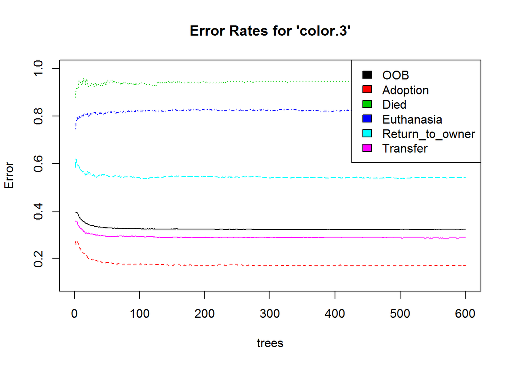

```r
#plotting model performance
plot(color.3, ylim=c(0.1,1),main="Error Rates for 'color.3'")
legend("topright", colnames(color.3$err.rate),fill=1:6)
```

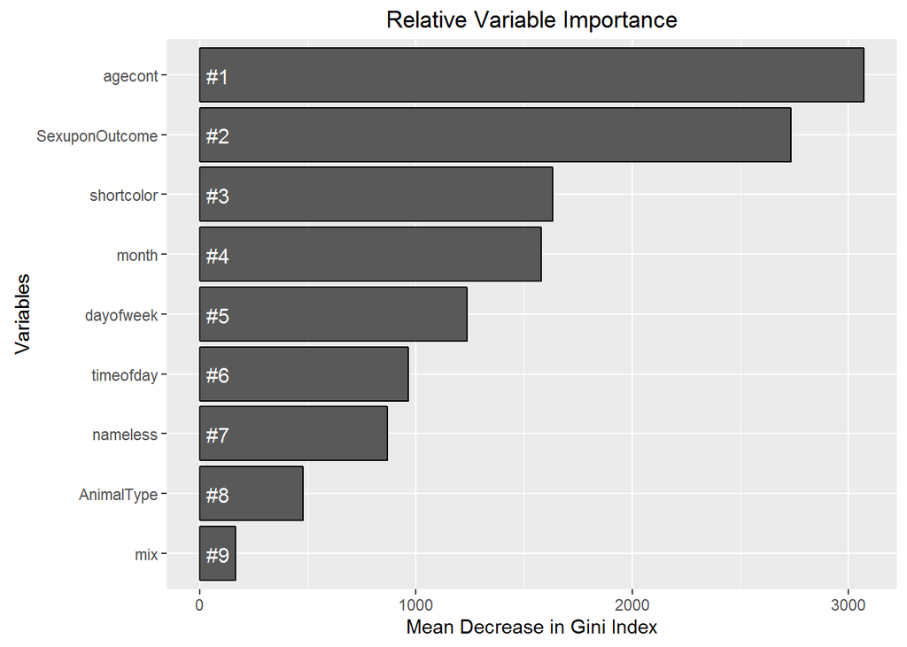

```r
#creating function for plotting variable importance (I'm making a function so that this will be quicker next time I need to do this)
VIplot<-function(RFmod,...){
      suppressMessages(require(randomForest))
      VI<-importance(RFmod,...)
      VI<-data.frame(vars=row.names(VI),imp=VI[,1])
      suppressMessages(require(dplyr))
      VI<-VI %>% arrange(desc(imp))
      VI$vars<-factor(VI$vars,levels=rev(VI$vars))
      for(i in 1:nrow(VI)){
            VI$rank[i]<-paste0("#",i)
      }
      suppressMessages(require(ggplot2))
      ggplot(VI,aes(x=vars,y=imp))+
            geom_bar(stat="identity",color="black")+
            coord_flip()+
            geom_text(aes(x=vars,y=max(VI$imp)/100,label=rank),hjust=0,vjust=0.55,size=4,color="white")+
            labs(x="Variables",y="Mean Decrease in Gini Index",title="Relative Variable Importance")
}

#plotting variable importance
VIplot(color.3)
```

Looking at our error rate plot, we can see that our model does a great job of predicting adoptions and transfers but is very poor at correctly predicting deaths and euthanizations. I believe that this is due to the majority of our observations having either adoption or transfer as their outcomes while a very small amount die or get euthanized. The small sample of animals that died or where euthanized makes it harder for the model to pick up on what features result in these outcomes, since its essentially grasping at straws when it tries to correctly classify those outcomes. All things considered, I still think this is the best model we can come up with given the situation, so we’ll just have to accept this as the current state of affairs and make note of this moving forward (especially if this model were to ever be used to predict more animals’ outcomes).

All things considered, we have a pretty solid model based on a thorough exploration of our data set (given this being my first real project).

## Concluding Thoughs and Potential Improvements

To conclude, I’m very happy with how this project turned out. I got to touch up my knowledge of data exploration and the model building process, and flexing my R abilities to make everything come together the way it did was a great exercise that helped me solidify my existing knowledge and learn some more new things.

But where could we have improved? If I had the technical know-how, I would try creating a boosted classification tree model instead of a random forest. Using boosting as a learning algorithm would allow our model to improve its performance in areas it’s performing poorly, like predicting euthanizations and death. The main reason I did not go this route is that I have yet to acquire the technical knowledge necessary to properly implement a boosted classification tree model in R; I’m only 8 chapters deep into Introduction to Statistical Learning and 3 chapters into Applied Predictive Modeling. Another improvement over boosting would be to create an ensemble of boosting and other models (like random forest) in conjunction. This would offer a further improvement in performance. Also, as previously mentioned in our exploration of the variable `Breed`, if we had more knowledge about different breeds and their respective characteristics we could try creating other variables (determined by the animal’s breed) that may help explain animals’ outcomes. This may be hard though, since not every animal will be a stereotype of its breed; if the data set also included values for variables like height and weight, I suspect our model would do a much better job of predicting euthanasia and death (it would be able to find animals that are old and have weight problems, indicating imminent death). Another idea would be to look at each animal’s breed and find the average age for each breed; if the animal in question exceeding the average age of its breed, I suspect it would be more likely to die or be euthanized as well.

Thank you for reading my project, any feedback would be highly appreciated and fully welcomed. Feel free to email me at n_martinez@u.pacific.edu with any tips or suggestions.